# Analysis on Methods of Predicting Energy Consumption

Fall 2019

Natalie Fedorova - Performed spatial predictive modeling on census tract level, and model validation with Howard et al.

Owen McGrattan - Performed temporal predictive modeling on building level.

# Abstract (5 points)

The research domain in predicting electricity consumption is already quite broad, using both high-level methodologies and robust-system modeling. Because both city governments and their residents hold stock in ensuring that energy is being used efficiently, the reality of climate change poses a challenge for cities to reduce their $CO_2$ pollution by examining how energy efficient their buildings are. If areas vulnerable to energy losses can be identified, then resources like retrofitting measures or installation of distributed generation can be delivered, boosting a resilient energy landscape. Addressing this need, we chose Chicago, IL as our core city to model, and we also separated our analysis into a spatial component and a temporal component in order to see which approach yielded stronger results. In the spatial analysis, we broke down our observations into census tract groupings and used a combination of building characteristics and median household income as our feature space. In our temporal component, we first generated some models to look at predicting a yearly consumption total in kWh, and then transitioned to generating separate models for each month within a year in order to see if there are consistencies in model strength across months. Because of the heavy skew in the density distribution of energy use intensity, no model constructed was ever strong across training, testing and cross-validation, so instead a healthy balance was maintained, resulting in average household age and median income being top-performing predictors. While predicting on a yearly total generated a strong model, this strength was very noisy when individual models were built on months, suggesting that there are some additional features that could help us elucidate consumption behavior on the building or census tract level, which ultimately points to a data issue.

# Project Background (5 points)

Predicting electricity and energy consumption across various scopes of space and time has been a long-time topic of interest amongst researchers and stakeholders in the energy market. In the wake of climate change, establishing energy efficient building design and promoting smart electricity use are two major ways cities can mitigate their contributions to global $CO_2$ emissions. If cities can identify the areas where consumption per square meter, or energy end use intensity, is relatively higher, then they can allocate aid in the form of retrofitting or even look towards establishing strategic deployment of distributed energy generation, such as at-home or commercial rooftop solar panels. Moreover, metrics of consumption can help to complete the picture of a city's welfare if correlation can be established between consumption rates and other known parameters of welfare assessment.

High-level research has already been conducted on predicting consumption. For example, Jones et al. explores modeling UC Berkeley's Sutardja Dai Hall, using several modeling approaches to predict within a small window of time, and still could not get a highly performing model because it had to capture the hourly variation in consumption while also responding strongly to the chosen predictors. This is the core issue with mapping consumption: it is difficult to fine-tune prediction in the abstract sense without making many separate models specific to one area, or one time period. Beyond that, from the perspective of applying these models in real life and broadly sourcing relevant data, there is a tension between trying to build single-parameter models, like in the study conducted in Howard et al. where just square footage was used to predict energy use (delivering a coefficient of energy use intensity), and using many parameters that may be more difficult to obtain data for, resulting in models with limited sharing potential. Despite using readily-available U.S. city data, it was difficult to find comprehensive building data that had robust granularity and was recent. Given this, we turn to broad building data from Allegheny County, New York state, and the city of Chicago to try and gather a sense of electrical consumption variations over a multi-year timespan within a building type. It must be noted that our conclusions in this space are also limited due to the lack of information on infrastructural changes that would affect consumption, such as the introduction and installation of LED lighting en masse to much of the nation.

Ultimately, the approach to predicting electricity consumption is highly dependent on the immediate applications of the model, and it is almost impossible to build a one-size-fits-all model even within one scope, such as space or time. From this, we decided to focus our work on the city of Chicago and try a few different layers of analysis in hopes of using many general building features to predict on a spatial scale, and also on a temporal scale. One part of the analysis is a spatial regression on the census tract level, where the aim is to predict the total energy intensity for each census tract in Chicago in 2010. The parameters used to frame this prediction include building characteristic totals broken down into building subtypes, as well as median household income for a given tract. Another part of our regression analysis is exploring total energy consumption on the individual building level for both yearly and monthly timescales. The aim is to draw out identifiable characteristics of electricity consumption outside of square footage and discern where the variance in electrical consumption may lie.

# Project Objective (5 points)

The central objective of this project is to analyze which methods of predicting energy consumption work best on a citywide scale like Chicago, IL, and whether we can extract more accuracy using an approach that predicts over some time period, or over spatial increments. Determining consumption on some scale is relevant to the reality of climate change in that increasing the energy efficiency of buildings can help to reduce city-wide emissions, to assess the need to integrate demand-response measures, and to allocate distributed generation resources. Moreover, bringing in a parameter like household income and measuring its significance in energy modeling can help us ascertain if energy use intensity can serve as an indicator of welfare. Lastly, we aim to expand on the existing domain by predicting a coefficient of energy end-use intensity given square footage while predicting energy use, parallel to the study done in Howard et. al, and seeing how the prediction performs alongside measured energy intensity.

# Input Data Description (5 points)

1. Load Project Dependencies
2. Data Origins
3. Structure, Granularity, Scope, Temporality, Faithfulness (SGSTF)

### 0. Load Project Dependencies

```python
# Load Dependencies

import numpy as np
import pandas as pd
import seaborn as sns
import sklearn
import matplotlib.pyplot as plt

from sklearn.linear_model import Lasso
from sklearn.preprocessing import LabelEncoder
import statsmodels.api as sm
from sklearn.linear_model import LinearRegression
from sklearn.linear_model import ElasticNet
from sklearn.linear_model import Lasso
from sklearn.linear_model import Ridge
from sklearn.model_selection import GridSearchCV
from sklearn.ensemble import RandomForestRegressor
from sklearn.neighbors import KNeighborsRegressor
from sklearn.model_selection import KFold
from sklearn.metrics import mean_squared_error
from sklearn.model_selection import train_test_split
from sklearn import preprocessing
from sklearn.preprocessing import PolynomialFeatures
from sklearn.model_selection import cross_val_score
from sklearn.ensemble import GradientBoostingRegressor

import warnings
warnings.filterwarnings('ignore')
np.random.seed(1)
pd.set_option('display.max_columns', 999)
```

### 1. Data Origins

[Chicago Energy Usage 2010](https://data.cityofchicago.org/Environment-Sustainable-Development/Energy-Usage-2010/8yq3-m6wp/data?fbclid=IwAR22_vWQaCS6LG6YM8zuwww31hV3clxIs7FGwt8krfXSkretaGkNKGQxm6U) is sourced from the Chicago Data Portal, and was accessible directly from the site via a downloadable .csv file. The set itself was found using a Google search.

[Income by Location](https://datausa.io/profile/geo/chicago-il) was taken from "datausa", and was found using a Google search that led to an interactive map whose tabulated data source was available for download in .csv format.

[New York State Government Building Energy Use Intensity Data: Beginning State Fiscal Year 2010](https://data.ny.gov/Energy-Environment/New-York-State-Government-Building-Energy-Use-Inte/nfvi-5nt4/data) is sourced from the New York State Government data access portal, and the .csv file was directly downloadable from a data interaction API labeled with the set name. The set was discovered using Google.

[Allegheny County Municipal Building Energy Usage](https://catalog.data.gov/dataset/municipal-building-energy-usage?fbclid=IwAR2V0tzi8IXHRQ797KL230V44K_LhGa9nnlTG1zEYl5Ytx85rQF27ZxxI20) was retrieved from data.gov, a governmental database, and the .xlsx file was obtainable from the dataset webpage through a download link. This set was found using Google search.

Lastly, [Chicago Energy Benchmarking](https://data.cityofchicago.org/Environment-Sustainable-Development/Chicago-Energy-Benchmarking/xq83-jr8c) was also taken from the Chicago Data Portal, with the same data accessibility features, and was discovered through Google search.

### 2. Structure, Granularity, Scope, Temporality, Faithfulness (SGSTF)

[Chicago Energy Usage 2010](https://data.cityofchicago.org/Environment-Sustainable-Development/Energy-Usage-2010/8yq3-m6wp/data?fbclid=IwAR22_vWQaCS6LG6YM8zuwww31hV3clxIs7FGwt8krfXSkretaGkNKGQxm6U)

[Income by Location](https://datausa.io/profile/geo/chicago-il)

- Structure: This dataset is in .csv format, where where each row represents a distinct census tract within 2013-2017 Cook County, IL. The columns contain information about the location of the census tract, its identification number, and the median household income as well as an associated margin of error for each tract. There is an additional column that tells us that we are not breaking the income information down by race, instead looking at the total population.
- Granularity: Each record is a census tract in Cook County at a specified year between 2013-2017, and the income at this level for each year is summarized using the median value. We will later be matching each 2013 median income value with the corresponding census tracts in the Chicago Energy Usage 2010 dataset, though we recognize the obvious mismatch between the sampled years. This is due to lack of accessible energy and income data that either is more recent or farther in the past, respectively.
- Scope: This dataset encompasses 2013 to 2017, and looks at Cook County census tracts, which is broader than the scope of our analysis, so we will use a subset (in time and space) of this set for our modeling needs.
- Temporality: Time is captured on a yearly basis over the span of five years, and is represented as a series of individual observations in each tract for a given year. There are no null values to remove for yearly data.
- Faithfulness: The dataset is very clean. It has an additional component that classifies the racial composition of each observation that is, for our purposes, not needed, but this is probably because the dataset was generated as part of a larger set, and does not represent any shortcoming of the data.

[New York State Government Building Energy Use Intensity Data: Beginning State Fiscal Year 2010](https://data.ny.gov/Energy-Environment/New-York-State-Government-Building-Energy-Use-Inte/nfvi-5nt4/data)

- Structure: This is a csv formatted file where each row represents a given state building in a given year. The columns contain general information like address, zip code, floor area, and source kBtu.
- Granularity: Each record is for a different municipal building in New York state for different years.
- Scope: The dataset covers some 300 or so buildings in New York state with dates ranging from 2010 to 2017.
- Temporality: Each of the date periods is represented as a two year interval (i.e. 2010-11). I would normally be concerned about this but for the purposes of measuring variance across buildings we are only looking within our own set so it is okay.
- Faithfulness: There is not a lot of data outside of electricity consumption to be explored here but the dataset itself is very clean.

[Allegheny County Municipal Building Energy Usage](https://catalog.data.gov/dataset/municipal-building-energy-usage?fbclid=IwAR2V0tzi8IXHRQ797KL230V44K_LhGa9nnlTG1zEYl5Ytx85rQF27ZxxI20)

- Structure: This is a csv formatted file where each row represents a given building for a given year much like the previous dataset. The columns contain information largely on building energy consumption which we are largely not concerned with.
- Granularity: Each record is for a municipal building in Allegheny County for different years.
- Scope: The data set covers a few hundred buildings from 2009-2014.
- Temporality: Each date period represents consumption over that year. This date formatting is in line with everything else in the project and is easier for interpretability than the dataset above.
- Faithfulness: Again we have a clean dataset but there are a lot of column values that are of little value to us. We’re really only looking for electricity consumption here.

[Chicago Energy Benchmarking](https://data.cityofchicago.org/Environment-Sustainable-Development/Chicago-Energy-Benchmarking/xq83-jr8c)

```python
# Load Data Sources
chi = pd.read_csv('Energy_Usage_2010.csv')
income = pd.read_csv('Income by Location.csv')
ny_municipal = pd.read_csv('New_York_State_Government_Building_Energy_Use_Intensity_Data__Beginning_State_Fiscal_Year_2010.csv')
all_county = pd.read_excel('municpal-building-energy-use-2009-2014.xlsx')
chi_bench = pd.read_csv('Chicago_Energy_Benchmarking.csv')
```

```python
# Chicago Energy Usage 2010
chi.head()
```

|  | COMMUNITY AREA NAME | CENSUS BLOCK | BUILDING TYPE | BUILDING_SUBTYPE | KWH JANUARY 2010 | KWH FEBRUARY 2010 | KWH MARCH 2010 | KWH APRIL 2010 | KWH MAY 2010 | KWH JUNE 2010 | KWH JULY 2010 | KWH AUGUST 2010 | KWH SEPTEMBER 2010 | KWH OCTOBER 2010 | KWH NOVEMBER 2010 | KWH DECEMBER 2010 | TOTAL KWH | ELECTRICITY ACCOUNTS | ZERO KWH ACCOUNTS | THERM JANUARY 2010 | THERM FEBRUARY 2010 | THERM MARCH 2010 | TERM APRIL 2010 | THERM MAY 2010 | THERM JUNE 2010 | THERM JULY 2010 | THERM AUGUST 2010 | THERM SEPTEMBER 2010 | THERM OCTOBER 2010 | … |
| --- | --- | --- | --- | --- | --- | --- | --- | --- | --- | --- | --- | --- | --- | --- | --- | --- | --- | --- | --- | --- | --- | --- | --- | --- | --- | --- | --- | --- | --- | --- |
| 0 | Archer Heights | 1.703157e+14 | Residential | Multi < 7 | NaN | NaN | NaN | NaN | NaN | NaN | NaN | NaN | NaN | NaN | NaN | NaN | NaN | NaN | 0 | 2326.0 | 2131.0 | 1400.0 | 620.0 | 502.0 | 224.0 | 222.0 | 187.0 | 197.0 | 252.0 | … |
| 1 | Ashburn | 1.703170e+14 | Residential | Multi 7+ | 7334.0 | 7741.0 | 4214.0 | 4284.0 | 2518.0 | 4273.0 | 4566.0 | 2787.0 | 3357.0 | 5540.0 | 15774.0 | 19676.0 | 82064.0 | 8 | 3 | NaN | NaN | NaN | NaN | NaN | NaN | NaN | NaN | NaN | NaN | … |
| 2 | Auburn Gresham | 1.703171e+14 | Commercial | Multi < 7 | NaN | NaN | NaN | NaN | NaN | NaN | NaN | NaN | NaN | NaN | NaN | NaN | NaN | NaN | 7 | 1561.0 | 1388.0 | 1507.0 | 701.0 | 486.0 | 380.0 | 18.0 | 16.0 | NaN | NaN | … |
| 3 | Austin | 1.703125e+14 | Commercial | Multi < 7 | NaN | NaN | NaN | NaN | NaN | NaN | NaN | NaN | NaN | NaN | NaN | NaN | NaN | NaN | 2 | NaN | NaN | NaN | NaN | NaN | NaN | NaN | NaN | NaN | NaN | … |
| 4 | Austin | 1.703125e+14 | Commercial | Multi < 7 | NaN | NaN | NaN | NaN | NaN | NaN | NaN | NaN | NaN | NaN | NaN | NaN | NaN | NaN | 3 | 310.0 | 268.0 | 163.0 | 77.0 | 57.0 | 23.0 | 19.0 | 8.0 | 14.0 | 10.0 | … |

```python
# Building Subtypes, Noting Presence of NaN values
[chi["BUILDING TYPE"].unique(), chi["BUILDING_SUBTYPE"].unique()]
```

```
[array(['Residential', 'Commercial', 'Industrial', nan], dtype=object),
 array(['Multi < 7', 'Multi 7+', 'Commercial', 'Single Family',
        'Municipal', 'Industrial', nan], dtype=object)]
```

```python
# Building Characteristics to Examine
chi[chi.columns[len(chi.columns)-10:]].head()
```

|  | TOTAL POPULATION | TOTAL UNITS | AVERAGE STORIES | AVERAGE BUILDING AGE | AVERAGE HOUSESIZE | OCCUPIED UNITS | OCCUPIED UNITS PERCENTAGE | RENTER-OCCUPIED HOUSING UNITS | RENTER-OCCUPIED HOUSING PERCENTAGE | OCCUPIED HOUSING UNITS |
| --- | --- | --- | --- | --- | --- | --- | --- | --- | --- | --- |
| 0 | 89.0 | 24.0 | 2.0 | 71.33 | 3.87 | 23.0 | 0.9582 | 9.0 | 0.3910 | 23.0 |
| 1 | 112.0 | 67.0 | 2.0 | 41.00 | 1.81 | 62.0 | 0.9254 | 50.0 | 0.8059 | 62.0 |
| 2 | 102.0 | 48.0 | 3.0 | 86.00 | 3.00 | 34.0 | 0.7082 | 23.0 | 0.6759 | 34.0 |
| 3 | 121.0 | 56.0 | 2.0 | 84.00 | 2.95 | 41.0 | 0.7321 | 32.0 | 0.7800 | 41.0 |
| 4 | 62.0 | 23.0 | 2.0 | 85.00 | 3.26 | 19.0 | 0.8261 | 11.0 | 0.5790 | 19.0 |

```python
# Income by Location
income.head()
```

|  | ID Year | Year | ID Race | Race | Household Income by Race | Household Income by Race Moe | Geography | ID Geography |
| --- | --- | --- | --- | --- | --- | --- | --- | --- |
| 0 | 2017 | 2017 | 0 | Total | 67391 | 8281.0 | Census Tract 1708, Cook County, IL | 14000US17031170800 |
| 1 | 2017 | 2017 | 0 | Total | 34643 | 11755.0 | Census Tract 8408.01, DuPage County, IL | 14000US17043840801 |
| 2 | 2017 | 2017 | 0 | Total | 80625 | 23252.0 | Census Tract 7005.02, Cook County, IL | 14000US17031700502 |
| 3 | 2017 | 2017 | 0 | Total | 40841 | 7069.0 | Census Tract 102.01, Cook County, IL | 14000US17031010201 |
| 4 | 2017 | 2017 | 0 | Total | 36563 | 8731.0 | Census Tract 102.02, Cook County, IL | 14000US17031010202 |

```python
# Decribe 2013 Income Distribution, noting right-hand skew
income.loc[income["Year"] == 2013][["Household Income by Race"]].describe()
```

|  | Household Income by Race |
| --- | --- |
| count | 801.000000 |
| mean | 48385.278402 |
| std | 24533.902973 |
| min | 5725.000000 |
| 25% | 31029.000000 |
| 50% | 42204.000000 |
| 75% | 60373.000000 |
| max | 147738.000000 |

```python
# New York Municipal Building Data
ny_municipal.head()
```

|  | Agency Name | Building/Facility Name | ZIP Code | Year | Gross Floor Area | Source kBtu | Source EUI |
| --- | --- | --- | --- | --- | --- | --- | --- |
| 0 | Agriculture and Markets | NY State Fair | 13209 | 2016-17 | 706854 | 87977450 | 124.46 |
| 1 | CUNY | Baruch College Campus | 10010 | 2016-17 | 1572633 | 329158700 | 209.30 |
| 2 | CUNY | Brooklyn College Campus | 11210 | 2016-17 | 2371951 | 769089350 | 324.24 |
| 3 | CUNY | Central Office Campus | 10075 | 2016-17 | 124514 | 39475350 | 317.04 |
| 4 | CUNY | City College Of New York Campus | 10031 | 2016-17 | 3353318 | 1142413000 | 340.68 |

```python
ny_municipal.describe()
```

|  | ZIP Code | Gross Floor Area | Source kBtu | Source EUI |
| --- | --- | --- | --- | --- |
| count | 2605.000000 | 2.605000e+03 | 2.605000e+03 | 2602.000000 |
| mean | 12402.975048 | 5.805641e+05 | 1.378078e+08 | 247.389185 |
| std | 1483.010563 | 1.280500e+06 | 3.390415e+08 | 309.584430 |
| min | 10001.000000 | 0.000000e+00 | -3.249275e+08 | -574.430000 |
| 25% | 11217.000000 | 4.936300e+04 | 7.848040e+06 | 129.827500 |
| 50% | 12458.000000 | 1.589700e+05 | 3.998291e+07 | 197.600000 |
| 75% | 13669.000000 | 5.656500e+05 | 1.365469e+08 | 286.507500 |
| max | 14901.000000 | 1.229841e+07 | 3.882475e+09 | 5787.000000 |

```python
# Alleghany County Building Information
all_county.head()
```

|  | Property Id | Property Name | Address 1 | Property GFA - Self-Reported (ft²) | Year Ending | Site EUI (kBtu/ft²) | Weather Normalized Site EUI (kBtu/ft²) | Source EUI (kBtu/ft²) | Weather Normalized Source EUI (kBtu/ft²) | Electricity Use - Grid Purchase (kBtu) | Electricity Use - Grid Purchase (kWh) | Weather Normalized Site Electricity (kWh) | Natural Gas Use (kBtu) | Natural Gas Use (therms) | Weather Normalized Site Natural Gas Use (therms) | District Steam Use (kBtu) | Total GHG Emissions (Metric Tons CO2e) | Total GHG Emissions Intensity (kgCO2e/ft²) | Energy Cost ($) | Energy Cost Intensity ($/ft²) |
| --- | --- | --- | --- | --- | --- | --- | --- | --- | --- | --- | --- | --- | --- | --- | --- | --- | --- | --- | --- | --- |
| 0 | 3575381 | Ammon Recreation Center | 2217 Bedford Ave | 14951 | 2014-09-30 | 125.2 | 121.5 | 232.3 | 225.2 | 721406 | 211432 | 204501 | 1.15011e+06 | 11501.1 | 11193 | Not Available | 206 | 13.8 | 30473 | 2.04 |
| 1 | 3575381 | Ammon Recreation Center | 2217 Bedford Ave | 14951 | 2013-09-30 | 143.6 | 146.5 | 239.5 | 245 | 634925 | 186086 | 191115 | 1.51199e+06 | 15119.9 | 15384.7 | Not Available | 207.9 | 13.9 | 32265.3 | 2.16 |
| 2 | 3575381 | Ammon Recreation Center | 2217 Bedford Ave | 14951 | 2012-09-30 | 102.4 | 114 | 172.6 | 181.2 | 465002 | 136284 | 128953 | 1.0667e+06 | 10667 | 12644.2 | Not Available | 150.1 | 10 | 25882.1 | 1.73 |
| 3 | 3575381 | Ammon Recreation Center | 2217 Bedford Ave | 14951 | 2011-09-30 | 145.8 | 141.3 | 232.7 | 222.7 | 569412 | 166885 | 155904 | 1.61083e+06 | 16108.3 | 15803.5 | Not Available | 200 | 13.4 | 35425.3 | 2.37 |
| 4 | 3575381 | Ammon Recreation Center | 2217 Bedford Ave | 14951 | 2010-09-30 | 142.8 | 143.6 | 244.3 | 242.3 | 674784 | 197768 | 191835 | 1.46088e+06 | 14608.8 | 14923.6 | Not Available | 213.2 | 14.3 | 38210.7 | 2.56 |

```python
all_county.groupby("Year Ending").mean()
```

| Year Ending | Property Id | Property GFA - Self-Reported (ft²) |
| --- | --- | --- |
| 2009-09-30 | 3.584620e+06 | 12752.841727 |
| 2010-09-30 | 3.584620e+06 | 12752.841727 |
| 2011-09-30 | 3.584620e+06 | 12752.841727 |
| 2012-09-30 | 3.584620e+06 | 12752.841727 |
| 2013-09-30 | 3.584620e+06 | 12752.841727 |
| 2014-09-30 | 3.584620e+06 | 12752.841727 |

```python
# Chicago Benchmarking Data
chi_bench.head()
```

|  | Data Year | ID | Property Name | Address | ZIP Code | Community Area | Primary Property Type | Gross Floor Area - Buildings (sq ft) | Year Built | # of Buildings | ENERGY STAR Score | Electricity Use (kBtu) | Natural Gas Use (kBtu) | District Steam Use (kBtu) | District Chilled Water Use (kBtu) | All Other Fuel Use (kBtu) | Site EUI (kBtu/sq ft) | Source EUI (kBtu/sq ft) | Weather Normalized Site EUI (kBtu/sq ft) | Weather Normalized Source EUI (kBtu/sq ft) | Total GHG Emissions (Metric Tons CO2e) | GHG Intensity (kg CO2e/sq ft) | Latitude | Longitude | Location |
| --- | --- | --- | --- | --- | --- | --- | --- | --- | --- | --- | --- | --- | --- | --- | --- | --- | --- | --- | --- | --- | --- | --- | --- | --- | --- |
| 0 | 2015 | 250009 | Malcolm X College | 1900 West Van Buren Street | 60612 | NEAR WEST SIDE | College/University | 541575.0 | 1971.0 | 1 | NaN | 25403152.0 | 29511031.0 | NaN | NaN | NaN | 101.4 | 204.5 | 105.5 | 208.1 | 6671.0 | 12.3 | 41.876251 | -87.674127 | (41.876251, -87.674127) |
| 1 | 2015 | 250127 | Bernard Mitchell Hospital | 5815 S. Maryland Av. | 60637 | HYDE PARK | Hospital (General Medical & Surgical) | 430772.0 | 1983.0 | 1 | 10.0 | 50618112.0 | NaN | 56440384.0 | NaN | NaN | 248.5 | 526.6 | 251.3 | 530.0 | 13917.0 | 32.3 | 41.789224 | -87.604896 | (41.789224, -87.604896) |
| 2 | 2015 | 251337 | The Theatre School | 2350 N. Racine | 60614 | LINCOLN PARK | College/University | 163000.0 | 2013.0 | 1 | NaN | 5526792.0 | 6892302.0 | NaN | NaN | NaN | 76.2 | 150.9 | 77.6 | 151.8 | 1477.0 | 9.1 | 41.924672 | -87.658471 | (41.924672, -87.658471) |
| 3 | 2015 | 250051 | Simeon Caree-CPS | 8235 S VINCENNES AVE | 60620 | CHATHAM | K-12 School | 284691.0 | 2003.0 | 1 | 26.0 | 13717564.0 | 16385844.0 | NaN | NaN | NaN | 105.7 | 211.7 | 109.6 | 214.3 | 3626.0 | 12.7 | 41.744236 | -87.635863 | (41.744236, -87.635863) |
| 4 | 2015 | 138605 | Kennedy Plaza BK, L.L.C. | 3300 W. Belmont Avenue | 60618 | AVONDALE | Strip Mall | 77385.0 | 1977.0 | 1 | NaN | 4925454.0 | 3810800.0 | NaN | NaN | NaN | 112.9 | 251.6 | 112.9 | 251.6 | 1192.0 | 15.4 | 41.939347 | -87.710159 | (41.939347, -87.710159) |

```python
chi_bench[["Site EUI (kBtu/sq ft)"]].describe()
```

|  | Site EUI (kBtu/sq ft) |
| --- | --- |
| count | 7213.000000 |
| mean | 99.460474 |
| std | 190.245744 |
| min | 0.200000 |
| 25% | 62.700000 |
| 50% | 80.300000 |
| 75% | 102.200000 |
| max | 8059.600000 |

# Data Cleaning (10 points)

**Note: There are some reduncies in data loading and cleaning due to the parallel processes involved in each quantitative analysis, so this section is enumerated appropriately to follow each analysis separately.**

1. Data Cleaning - Yearly & Monthly Analysis
2. Data Cleaning - Spatial Analysis

### 1. Data Cleaning - Yearly & Monthly Analysis

```python
# import Chicago dataset
chi = pd.read_csv('Energy_Usage_2010.csv')
income = pd.read_csv('Income by Location.csv')
chi.head()
```

|  | COMMUNITY AREA NAME | CENSUS BLOCK | BUILDING TYPE | BUILDING_SUBTYPE | KWH JANUARY 2010 | KWH FEBRUARY 2010 | KWH MARCH 2010 | KWH APRIL 2010 | KWH MAY 2010 | KWH JUNE 2010 | KWH JULY 2010 | KWH AUGUST 2010 | KWH SEPTEMBER 2010 | KWH OCTOBER 2010 | KWH NOVEMBER 2010 | KWH DECEMBER 2010 | TOTAL KWH | ELECTRICITY ACCOUNTS | ZERO KWH ACCOUNTS | THERM JANUARY 2010 | THERM FEBRUARY 2010 | THERM MARCH 2010 | TERM APRIL 2010 | THERM MAY 2010 | THERM JUNE 2010 | THERM JULY 2010 | THERM AUGUST 2010 | THERM SEPTEMBER 2010 | THERM OCTOBER 2010 | … |
| --- | --- | --- | --- | --- | --- | --- | --- | --- | --- | --- | --- | --- | --- | --- | --- | --- | --- | --- | --- | --- | --- | --- | --- | --- | --- | --- | --- | --- | --- | --- |
| 0 | Archer Heights | 1.703157e+14 | Residential | Multi < 7 | NaN | NaN | NaN | NaN | NaN | NaN | NaN | NaN | NaN | NaN | NaN | NaN | NaN | NaN | 0 | 2326.0 | 2131.0 | 1400.0 | 620.0 | 502.0 | 224.0 | 222.0 | 187.0 | 197.0 | 252.0 | … |
| 1 | Ashburn | 1.703170e+14 | Residential | Multi 7+ | 7334.0 | 7741.0 | 4214.0 | 4284.0 | 2518.0 | 4273.0 | 4566.0 | 2787.0 | 3357.0 | 5540.0 | 15774.0 | 19676.0 | 82064.0 | 8 | 3 | NaN | NaN | NaN | NaN | NaN | NaN | NaN | NaN | NaN | NaN | … |
| 2 | Auburn Gresham | 1.703171e+14 | Commercial | Multi < 7 | NaN | NaN | NaN | NaN | NaN | NaN | NaN | NaN | NaN | NaN | NaN | NaN | NaN | NaN | 7 | 1561.0 | 1388.0 | 1507.0 | 701.0 | 486.0 | 380.0 | 18.0 | 16.0 | NaN | NaN | … |
| 3 | Austin | 1.703125e+14 | Commercial | Multi < 7 | NaN | NaN | NaN | NaN | NaN | NaN | NaN | NaN | NaN | NaN | NaN | NaN | NaN | NaN | 2 | NaN | NaN | NaN | NaN | NaN | NaN | NaN | NaN | NaN | NaN | … |
| 4 | Austin | 1.703125e+14 | Commercial | Multi < 7 | NaN | NaN | NaN | NaN | NaN | NaN | NaN | NaN | NaN | NaN | NaN | NaN | NaN | NaN | 3 | 310.0 | 268.0 | 163.0 | 77.0 | 57.0 | 23.0 | 19.0 | 8.0 | 14.0 | 10.0 | … |

```python
# pull census tracts from census blocks, create census tract variable in income
chi['census_tract'] = np.array([str(chi['CENSUS BLOCK'].values[i])[:-6] for i in range(len(chi))])
income['census_tract'] = np.array([income['ID Geography'][i].split('US')[1] for i in range(len(income))])

# filter down income to the columns that we need only and the closest year (2013)
income = income[income['Year'] == 2013]
income = income[['Household Income by Race', 'census_tract']]

chi = pd.merge(chi, income, how = 'left', on = 'census_tract')
```

```python
# label encode for neighborhoods
le = LabelEncoder()
le.fit(chi['COMMUNITY AREA NAME'])
chi['COMMUNITY AREA NAME'] = le.transform(chi['COMMUNITY AREA NAME'])
```

```python
chi.columns
```

```
Index([u'COMMUNITY AREA NAME', u'CENSUS BLOCK', u'BUILDING TYPE',
       u'BUILDING_SUBTYPE', u'KWH JANUARY 2010', u'KWH FEBRUARY 2010',
       u'KWH MARCH 2010', u'KWH APRIL 2010', u'KWH MAY 2010', u'KWH JUNE 2010',
       u'KWH JULY 2010', u'KWH AUGUST 2010', u'KWH SEPTEMBER 2010',
       u'KWH OCTOBER 2010', u'KWH NOVEMBER 2010', u'KWH DECEMBER 2010',
       u'TOTAL KWH', u'ELECTRICITY ACCOUNTS', u'ZERO KWH ACCOUNTS',
       u'THERM JANUARY 2010', u'THERM FEBRUARY 2010', u'THERM MARCH 2010',
       u'TERM APRIL 2010', u'THERM MAY 2010', u'THERM JUNE 2010',
       u'THERM JULY 2010', u'THERM AUGUST 2010', u'THERM SEPTEMBER 2010',
       u'THERM OCTOBER 2010', u'THERM NOVEMBER 2010', u'THERM DECEMBER 2010',
       u'TOTAL THERMS', u'GAS ACCOUNTS', u'KWH TOTAL SQFT',
       u'THERMS TOTAL SQFT', u'KWH MEAN 2010', u'KWH STANDARD DEVIATION 2010',
       u'KWH MINIMUM 2010', u'KWH 1ST QUARTILE 2010', u'KWH 2ND QUARTILE 2010',
       u'KWH 3RD QUARTILE 2010', u'KWH MAXIMUM 2010', u'KWH SQFT MEAN 2010',
       u'KWH SQFT STANDARD DEVIATION 2010', u'KWH SQFT MINIMUM 2010',
       u'KWH SQFT 1ST QUARTILE 2010', u'KWH SQFT 2ND QUARTILE 2010',
       u'KWH SQFT 3RD QUARTILE 2010', u'KWH SQFT MAXIMUM 2010',
       u'THERM MEAN 2010', u'THERM STANDARD DEVIATION 2010',
       u'THERM MINIMUM 2010', u'THERM 1ST QUARTILE 2010',
       u'THERM 2ND QUARTILE 2010', u'THERM 3RD QUARTILE 2010',
       u'THERM MAXIMUM 2010', u'THERMS SQFT MEAN 2010',
       u'THERMS SQFT STANDARD DEVIATION 2010', u'THERMS SQFT MINIMUM 2010',
       u'THERMS SQFT 1ST QUARTILE 2010', u'THERMS SQFT 2ND QUARTILE 2010',
       u'THERMS SQFT 3RD QUARTILE 2010', u'THERMS SQFT MAXIMUM 2010',
       u'TOTAL POPULATION', u'TOTAL UNITS', u'AVERAGE STORIES',
       u'AVERAGE BUILDING AGE', u'AVERAGE HOUSESIZE', u'OCCUPIED UNITS',
       u'OCCUPIED UNITS PERCENTAGE', u'RENTER-OCCUPIED HOUSING UNITS',
       u'RENTER-OCCUPIED HOUSING PERCENTAGE', u'OCCUPIED HOUSING UNITS',
       u'census_tract', u'Household Income by Race'],
      dtype='object')
```

Just looking through the data we have a good amount of missing electrical data. However we ought to be careful in how we separate as often where there is missing electrical data there is thermal data and vicea versa. We should split into at least two different sets.

Also for the purposes of this set we want to remove columns that we will not use for prediction of our total electricity output response variable. Off the bat this includes the monthly totals for kwh and therm (if they even exist for rows in the electric set). In all we are most interested with the columns at the beginning and end of the set. It'll be better to pick these all out by hand.

```python
chi_electric = chi[np.isfinite(chi['TOTAL KWH'])]
```

```python
cols = ['COMMUNITY AREA NAME', 'CENSUS BLOCK',
       'BUILDING_SUBTYPE','TOTAL KWH', 'ELECTRICITY ACCOUNTS', 'ZERO KWH ACCOUNTS',
       'TOTAL THERMS', 'GAS ACCOUNTS',
        'KWH MEAN 2010',
        'TOTAL POPULATION', 'TOTAL UNITS', 'AVERAGE STORIES',
       'AVERAGE BUILDING AGE', 'AVERAGE HOUSESIZE', 'OCCUPIED UNITS',
       'OCCUPIED UNITS PERCENTAGE',
       'RENTER-OCCUPIED HOUSING PERCENTAGE',
        'Household Income by Race'
       ]
chi_electric = chi_electric[cols]
```

```python
# insert dummy cols for building sub type
dummy_sub = pd.get_dummies(chi_electric['BUILDING_SUBTYPE'])
chi_electric = pd.concat([chi_electric, dummy_sub], axis = 1)

# clean up ELECTRICITY and ZERO KW ELECTRICITY ACCOUNTS columns
chi_electric.replace('Less than 4', 3, inplace = True)


# drop any missing values
chi_electric.dropna(inplace = True)
```

We'll have more cleaning to do as we go ahead and we'll retroactively come back to this section for modification, but for now let's get an idea of what kinds of relationships we're looking at.

### 2. Data Cleaning - Spatial Analysis

```python
# Load Chicago Energy Usage 2010 dataset
chicago_2010 = pd.read_csv("Energy_Usage_2010.csv")
chicago_2010.head()
```

|  | COMMUNITY AREA NAME | CENSUS BLOCK | BUILDING TYPE | BUILDING_SUBTYPE | KWH JANUARY 2010 | KWH FEBRUARY 2010 | KWH MARCH 2010 | KWH APRIL 2010 | KWH MAY 2010 | KWH JUNE 2010 | KWH JULY 2010 | KWH AUGUST 2010 | KWH SEPTEMBER 2010 | KWH OCTOBER 2010 | KWH NOVEMBER 2010 | KWH DECEMBER 2010 | TOTAL KWH | ELECTRICITY ACCOUNTS | ZERO KWH ACCOUNTS | THERM JANUARY 2010 | THERM FEBRUARY 2010 | THERM MARCH 2010 | TERM APRIL 2010 | THERM MAY 2010 | THERM JUNE 2010 | THERM JULY 2010 | THERM AUGUST 2010 | THERM SEPTEMBER 2010 | THERM OCTOBER 2010 | … |
| --- | --- | --- | --- | --- | --- | --- | --- | --- | --- | --- | --- | --- | --- | --- | --- | --- | --- | --- | --- | --- | --- | --- | --- | --- | --- | --- | --- | --- | --- | --- |
| 0 | Archer Heights | 1.703157e+14 | Residential | Multi < 7 | NaN | NaN | NaN | NaN | NaN | NaN | NaN | NaN | NaN | NaN | NaN | NaN | NaN | NaN | 0 | 2326.0 | 2131.0 | 1400.0 | 620.0 | 502.0 | 224.0 | 222.0 | 187.0 | 197.0 | 252.0 | … |
| 1 | Ashburn | 1.703170e+14 | Residential | Multi 7+ | 7334.0 | 7741.0 | 4214.0 | 4284.0 | 2518.0 | 4273.0 | 4566.0 | 2787.0 | 3357.0 | 5540.0 | 15774.0 | 19676.0 | 82064.0 | 8 | 3 | NaN | NaN | NaN | NaN | NaN | NaN | NaN | NaN | NaN | NaN | … |
| 2 | Auburn Gresham | 1.703171e+14 | Commercial | Multi < 7 | NaN | NaN | NaN | NaN | NaN | NaN | NaN | NaN | NaN | NaN | NaN | NaN | NaN | NaN | 7 | 1561.0 | 1388.0 | 1507.0 | 701.0 | 486.0 | 380.0 | 18.0 | 16.0 | NaN | NaN | … |
| 3 | Austin | 1.703125e+14 | Commercial | Multi < 7 | NaN | NaN | NaN | NaN | NaN | NaN | NaN | NaN | NaN | NaN | NaN | NaN | NaN | NaN | 2 | NaN | NaN | NaN | NaN | NaN | NaN | NaN | NaN | NaN | NaN | … |
| 4 | Austin | 1.703125e+14 | Commercial | Multi < 7 | NaN | NaN | NaN | NaN | NaN | NaN | NaN | NaN | NaN | NaN | NaN | NaN | NaN | NaN | 3 | 310.0 | 268.0 | 163.0 | 77.0 | 57.0 | 23.0 | 19.0 | 8.0 | 14.0 | 10.0 | … |

```python
# Load Income by Location Dataset
income_by_location = pd.read_csv("Income by Location.csv")
income_by_location.head()
```

|  | ID Year | Year | ID Race | Race | Household Income by Race | Household Income by Race Moe | Geography | ID Geography |
| --- | --- | --- | --- | --- | --- | --- | --- | --- |
| 0 | 2017 | 2017 | 0 | Total | 67391 | 8281.0 | Census Tract 1708, Cook County, IL | 14000US17031170800 |
| 1 | 2017 | 2017 | 0 | Total | 34643 | 11755.0 | Census Tract 8408.01, DuPage County, IL | 14000US17043840801 |
| 2 | 2017 | 2017 | 0 | Total | 80625 | 23252.0 | Census Tract 7005.02, Cook County, IL | 14000US17031700502 |
| 3 | 2017 | 2017 | 0 | Total | 40841 | 7069.0 | Census Tract 102.01, Cook County, IL | 14000US17031010201 |
| 4 | 2017 | 2017 | 0 | Total | 36563 | 8731.0 | Census Tract 102.02, Cook County, IL | 14000US17031010202 |

```python
# Rename Income Column to something more intuitive
income_by_location["$ Median Household Income"] = income_by_location["Household Income by Race"]
# Slice the Geography IDs to extract the unique census tract code
income_ids = income_by_location["ID Geography"].astype(str)
income_ids = income_ids.str.slice(start=7)

# Add census tract column to existing income dataframe
income_by_location["Census Tract"] = income_ids

# Create dataframe that will be merged later which just has tract and income information
income_2013 = income_by_location[income_by_location["Year"] == 2013][["Census Tract", "$ Median Household Income"]].reset_index(drop=True)
```

```python
# Slice the Census Blocks to extract the unique census tract code
census_blocks = chicago_2010["CENSUS BLOCK"].astype(str)
# Add census tract column to existing energy dataframe
chicago_2010["CENSUS TRACT"] = census_blocks.str.slice(stop=11)
```

```python
# Establish parameters of interest, as well as each building type

census_tracts = chicago_2010["CENSUS TRACT"].unique() # 803 Census Tracts
features = ["TOTAL UNITS", "AVERAGE STORIES","AVERAGE BUILDING AGE",
            "AVERAGE HOUSESIZE","OCCUPIED UNITS","RENTER-OCCUPIED HOUSING UNITS",
            "OCCUPIED HOUSING UNITS"]
building_types = ["RDTL 7+", "RDTL <7", "COMM 7+", "COMM <7"]

# Convert the consumption columns to numbers and remove comma separators
chicago_quant_vars = chicago_2010[np.append(features,["TOTAL KWH", "KWH TOTAL SQFT"]) ].replace(to_replace =',', value = '', regex = True).astype(float)

# Concatenate both our features and components of the desired response variable into one dataframe
# Remove NaNs
chicago_all_vars = pd.concat([chicago_2010[["COMMUNITY AREA NAME", "CENSUS TRACT",
                                        "BUILDING TYPE", "BUILDING_SUBTYPE"]], chicago_quant_vars], axis=1).dropna(subset=["TOTAL KWH"])
```

```python
# Create a new dataframe that is grouped by census tract, where each feature from above
# is totaled for the census tract, but this total is split amongst each building type we consider.
# For each census tract, match the median houshold income from the second dataset as an additional feature

for i in range(len(census_tracts)):
    current_tract_df = chicago_all_vars[ chicago_all_vars["CENSUS TRACT"] == census_tracts[i]]
    dict_tract = {}
    for feature in range(len(features)):

        single_family = current_tract_df[current_tract_df["BUILDING_SUBTYPE"]  == 'Single Family'][ features[feature] ].sum()
        res_7plus = current_tract_df[(current_tract_df["BUILDING TYPE"]  == "Residential") &
                        (current_tract_df["BUILDING_SUBTYPE"]  == "Multi 7+")][ features[feature] ].sum()
        res_7less = current_tract_df[(current_tract_df["BUILDING TYPE"]  == "Residential") &
                        (current_tract_df["BUILDING_SUBTYPE"]  == "Multi < 7")][ features[feature] ].sum()
        comm_7plus = current_tract_df[(current_tract_df["BUILDING TYPE"]  == "Commercial") &
                        (current_tract_df["BUILDING_SUBTYPE"]  == "Commercial")][ features[feature] ].sum()
        comm_7less = current_tract_df[(current_tract_df["BUILDING TYPE"]  == "Commercial") &
                        (current_tract_df["BUILDING_SUBTYPE"]  == "Multi < 7")][ features[feature] ].sum()
        industrial = current_tract_df[(current_tract_df["BUILDING TYPE"]  == "Industrial")][ features[feature] ].sum()
        municipal = current_tract_df[(current_tract_df["BUILDING_SUBTYPE"]  == "Municipal")][ features[feature] ].sum()
        dict_tract.update(
        {features[feature]+" "+"SINGLE FAMILY": single_family,
         features[feature]+" "+building_types[0]: res_7plus,
         features[feature]+" "+building_types[1]: res_7less,
         features[feature]+" "+building_types[2]: comm_7plus,
         features[feature]+" "+building_types[3]: comm_7less,
         features[feature]+" "+"INDUSTRIAL": industrial,
         features[feature]+" "+"MUNICIPAL": municipal
        })
    dict_tract.update({
        "TOTAL KWH": [current_tract_df['TOTAL KWH'].sum()],
        "KWH/M^2 INTENSITY": [ (current_tract_df['TOTAL KWH'].sum())/ (current_tract_df["KWH TOTAL SQFT"].sum()) ],
        "MEDIAN INCOME": [income_2013[income_2013["Census Tract"] == census_tracts[i]]["$ Median Household Income"].astype(float).sum()]
    })
    to_cat = pd.DataFrame(data = dict_tract)
    if i > 0:
        chicago_vars_by_type = pd.concat([chicago_vars_by_type, to_cat]).reset_index(drop=True)
    else:
        chicago_vars_by_type = to_cat

chicago_vars_by_type.head()
```

|  | AVERAGE BUILDING AGE COMM 7+ | AVERAGE BUILDING AGE COMM <7 | AVERAGE BUILDING AGE INDUSTRIAL | AVERAGE BUILDING AGE MUNICIPAL | AVERAGE BUILDING AGE RDTL 7+ | AVERAGE BUILDING AGE RDTL <7 | AVERAGE BUILDING AGE SINGLE FAMILY | AVERAGE HOUSESIZE COMM 7+ | AVERAGE HOUSESIZE COMM <7 | AVERAGE HOUSESIZE INDUSTRIAL | AVERAGE HOUSESIZE MUNICIPAL | AVERAGE HOUSESIZE RDTL 7+ | AVERAGE HOUSESIZE RDTL <7 | AVERAGE HOUSESIZE SINGLE FAMILY | AVERAGE STORIES COMM 7+ | AVERAGE STORIES COMM <7 | AVERAGE STORIES INDUSTRIAL | AVERAGE STORIES MUNICIPAL | AVERAGE STORIES RDTL 7+ | AVERAGE STORIES RDTL <7 | AVERAGE STORIES SINGLE FAMILY | KWH/M^2 INTENSITY | MEDIAN INCOME | OCCUPIED HOUSING UNITS COMM 7+ | OCCUPIED HOUSING UNITS COMM <7 | OCCUPIED HOUSING UNITS INDUSTRIAL | OCCUPIED HOUSING UNITS MUNICIPAL | OCCUPIED HOUSING UNITS RDTL 7+ | OCCUPIED HOUSING UNITS RDTL <7 | … |
| --- | --- | --- | --- | --- | --- | --- | --- | --- | --- | --- | --- | --- | --- | --- | --- | --- | --- | --- | --- | --- | --- | --- | --- | --- | --- | --- | --- | --- | --- | --- |
| 0 | 432.00 | 53.0 | 0.0 | 0.0 | 0.0 | 1304.18 | 1283.63 | 26.20 | 5.15 | 0.0 | 0.00 | 0.00 | 53.14 | 50.48 | 12.00 | 4.0 | 0.0 | 0.0 | 0.0 | 31.02 | 20.61 | 8.634709 | 41250.0 | 123.0 | 53.0 | 0.0 | 0.0 | 0.0 | 342.0 | … |
| 1 | 715.75 | 172.0 | 0.0 | 0.0 | 82.0 | 1060.37 | 8994.06 | 36.36 | 11.88 | 0.0 | 0.00 | 3.28 | 53.45 | 464.93 | 25.53 | 9.0 | 0.0 | 0.0 | 4.0 | 41.50 | 233.70 | 7.878727 | 75087.0 | 131.0 | 79.0 | 0.0 | 0.0 | 79.0 | 369.0 | … |
| 2 | 324.10 | 223.5 | 0.0 | 0.0 | 705.0 | 2636.66 | 2847.86 | 11.48 | 22.42 | 0.0 | 2.85 | 22.03 | 86.90 | 113.90 | 10.87 | 15.0 | 0.0 | 1.0 | 25.0 | 84.67 | 46.53 | 5.447974 | 25307.0 | 67.0 | 452.0 | 0.0 | 13.0 | 347.0 | 1228.0 | … |
| 3 | 323.17 | 1105.5 | 0.0 | 0.0 | 320.0 | 3300.80 | 2081.40 | 16.00 | 52.96 | 0.0 | 0.00 | 11.69 | 135.02 | 112.01 | 10.17 | 34.5 | 0.0 | 0.0 | 12.0 | 84.39 | 46.34 | 6.491285 | 31997.0 | 83.0 | 469.0 | 0.0 | 0.0 | 74.0 | 1195.0 | … |
| 4 | 710.92 | 681.0 | 0.0 | 0.0 | 325.0 | 4364.52 | 3502.59 | 42.00 | 40.27 | 0.0 | 0.00 | 11.51 | 164.35 | 147.63 | 19.99 | 23.0 | 0.0 | 0.0 | 9.0 | 108.14 | 55.62 | 5.533954 | 36978.0 | 172.0 | 399.0 | 0.0 | 0.0 | 145.0 | 1672.0 | … |

I decided to flesh out the feature space as much as possible as I want to play to the strengths of the techniques we use in this class, where we let models perform feature selection or shrinkage while feeding them many different layers of the physical system we are exploring.

```python
# Separate the partially cleaned dataframe into the predictors and the response variable
X_all_vars = chicago_vars_by_type.drop(["TOTAL KWH","KWH/M^2 INTENSITY"], axis=1).reset_index(drop=True)
y_all_vars = chicago_vars_by_type[["KWH/M^2 INTENSITY"]]
```

```python
# Do one more sweep, through the predictor space now, and remove any tracts who are missing more than
# one variable but who also (upon previous inspection) have uncharacteristically high consumption totals
discard_array = []

for i in range(len(X_all_vars)):
    zero_counter = 0
    for indx in range(1,len(X_all_vars.columns)):
        if X_all_vars.iloc[i, indx] == 0.0:
            zero_counter += 1
    if zero_counter > len(X_all_vars.columns)*0.5:
        discard_array = np.append(discard_array, 1)
    else:
        discard_array = np.append(discard_array, 0)
```

```python
sum(discard_array)
```

```
52.0
```

```python
X_all_vars["Rows to Discard"] = discard_array
y_all_vars["Rows to Discard"] = discard_array
```

```python
X_all_vars = X_all_vars[X_all_vars["Rows to Discard"] == 0].reset_index(drop=True).drop("Rows to Discard", axis=1) # 775
y_all_vars = y_all_vars[y_all_vars["Rows to Discard"] == 0].reset_index(drop=True).drop("Rows to Discard", axis=1)
```

```python
# Normalize the feature space for the purposes of linear regression and k nearest neighbors

columns_to_pass = X_all_vars.columns
X_all_vars_normalized = pd.DataFrame(preprocessing.normalize(X_all_vars,axis=1), columns=columns_to_pass)
```

```python
len(X_all_vars)
```

```
751
```

```python
def plot_strength(X, y, y_pred, regression_name, set_type, model):
    x = np.linspace(0,20, 1000)

    y_2_0 = 2 * x
    y_0_5 = (.5) * x

    y_1_5 = (1.5) * x
    y_0_6 =  (.6667) * x
    plt.plot(x, x, color='green', linestyle='-.', alpha=.7)
    plt.plot(x, y_2_0, color='red', linestyle='-.',alpha=.7)
    plt.plot(x, y_0_5, color='red', linestyle='-.',alpha=.7)

    plt.plot(x, y_1_5, color='orange', linestyle='-.',alpha=.7)
    plt.plot(x, y_0_6, color='orange', linestyle='-.',alpha=.7)

    plt.scatter(y, y_pred)
    plt.xlabel(set_type+" y-values")
    plt.ylabel("Predicted "+set_type+" y-values")
    plt.title(regression_name)
    plt.xlim(0,20)
    plt.ylim(0,20)
    plt.text(15, .5, "R^2 = %0.3f "%(model.score(X, y)))

    plt.show()
```

This function above sets up a square-shaped scatterplot, with the observations on the x-axis and the predictions on the y-axis. If the fit is perfect, all points will lie on the green line, which has a slope of 1. If the fit is moderate, most of the points should lie between the green and orange boundaries, and if the fit is weaker, the points mostly lie between the orange and red boundaries.

# Data Summary and Exploratory Data Analysis (10 points)

1. Temporal Analysis
2. Spatial Analysis

### 1. Temporal Analysis

Before we go any further let's explore some of features first. Namely let's look at the distribution of kwh.

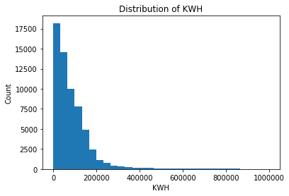

```python
# distribution of total kwh
plt.hist(chi_electric[chi_electric['TOTAL KWH'] < 1e6]['TOTAL KWH'], bins = 30)
plt.xlabel('KWH')
plt.ylabel('Count')
plt.title('Distribution of KWH')
plt.show()
```

To make any kind of a plot that shows a shape we had to exclude some outliers first. We still see a heavy right hand skew, something we ought to be careful of in our analysis going forward. Let's see the size of our buildings.

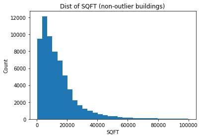

```python
plt.hist(chi[chi['KWH TOTAL SQFT'] < 1e5]['KWH TOTAL SQFT'], bins = 30)
plt.xlabel('SQFT')
plt.ylabel('Count')
plt.title('Dist of SQFT (non-outlier buildings)')
plt.show()
```

Again, to make a plot that was readable we had to exclude some of our outlier measurements but there's still a strong right-hand skew. Is there any large discrepancy in the counts of building types that we should be concerned with going forward?

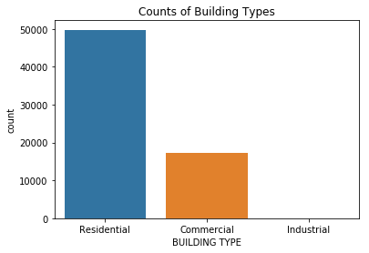

```python
sns.countplot(x = chi['BUILDING TYPE'])
plt.title("Counts of Building Types")
plt.show()
```

Our set is heavily dominated by residential buildings, comprising of nearly 50,000 observations in our dataframe with a still considerable portion of commercial buildings. I suspect the few industrial buildings are giving us our outlier observations.

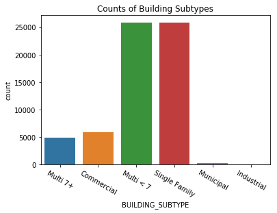

```python
a = sns.countplot(x = chi_electric['BUILDING_SUBTYPE'])
a.set_xticklabels(labels = chi_electric['BUILDING_SUBTYPE'].unique(), rotation = -30)
plt.title('Counts of Building Subtypes')
plt.show()
```

Taking a closer look and breaking down the chunk of residential buildings into subtypes we see that the majority are either multi-unit buildings with < 7 units or single family homes. There may be issues with our model being able to effectively utilize either classification due to large variance.

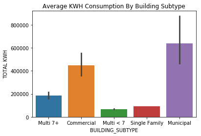

```python
sns.barplot(x = chi_electric[chi_electric['BUILDING_SUBTYPE'] != 'Industrial']['BUILDING_SUBTYPE'], y = chi_electric[chi_electric['BUILDING_SUBTYPE'] != 'Industrial']['TOTAL KWH'])
plt.title('Average KWH Consumption By Building Subtype')
plt.show()
```

But when we look at average consumption by building subtype we see that there isn't much difference between our less than 7 unit buildings and single family buildings. Each other subtype does separate itself quite clearly which should help in modeling. The industrial subtype was left off of this plot because it was so much greater than the rest.

### 2. Spatial Analysis

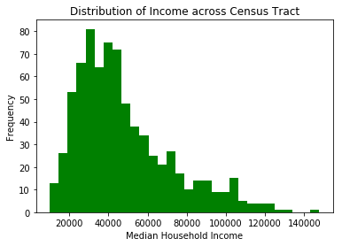

```python
plt.hist(X_all_vars['MEDIAN INCOME'], bins = 30, color='green')
plt.xlabel('Median Household Income')
plt.ylabel('Frequency')
plt.title('Distribution of Income across Census Tract')
plt.show()
```

```python
y_all_vars[["KWH/M^2 INTENSITY"]].describe()
```

|  | KWH/M^2 INTENSITY |
| --- | --- |
| count | 751.000000 |
| mean | 7.107757 |
| std | 5.845337 |
| min | 2.441883 |
| 25% | 5.213010 |
| 50% | 6.424147 |
| 75% | 7.568516 |
| max | 142.363240 |

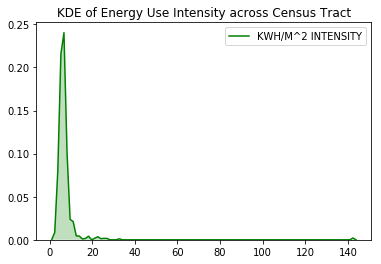

```python
sns.kdeplot(y_all_vars["KWH/M^2 INTENSITY"], shade=True, color="green", kernel='cos')
plt.title("KDE of Energy Use Intensity across Census Tract")
plt.show()
```

```python
param_values_for_max = X_all_vars_normalized[y_all_vars["KWH/M^2 INTENSITY"] == y_all_vars["KWH/M^2 INTENSITY"].max()].reset_index(drop=True)
param_values_for_max = param_values_for_max.T.reset_index()
param_values_for_max.head()
```

|  | index | 0 |
| --- | --- | --- |
| 0 | AVERAGE BUILDING AGE COMM 7+ | 0.006236 |
| 1 | AVERAGE BUILDING AGE COMM <7 | 0.009479 |
| 2 | AVERAGE BUILDING AGE INDUSTRIAL | 0.000000 |
| 3 | AVERAGE BUILDING AGE MUNICIPAL | 0.000000 |
| 4 | AVERAGE BUILDING AGE RDTL 7+ | 0.009593 |

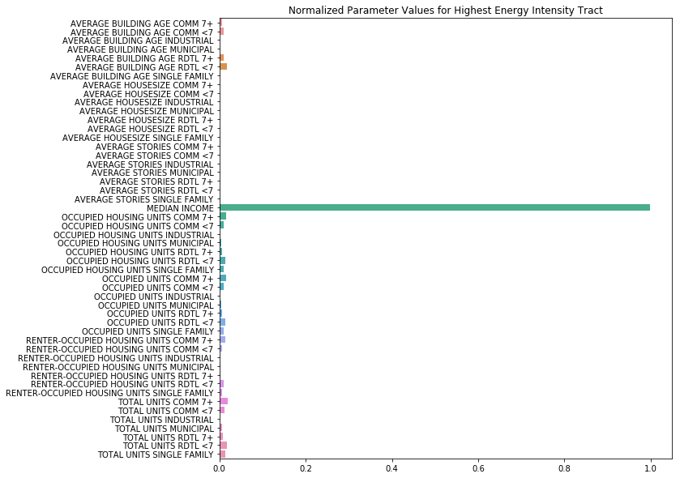

```python
fig, ax = plt.subplots(figsize=(10,10))
sns.barplot(x=0, y='index', data=param_values_for_max)
ax.set_xlabel("")
ax.set_ylabel("")
ax.set_title("Normalized Parameter Values for Highest Energy Intensity Tract")
plt.show()
```

From looking at both median household income distributions and the distribution of energy use intensity, it becomes clear the significance of the heavy right-hand skew, and how perhaps this dataset captures too much variance for a model to be able to quite accurately predict on a city-wide scale beyond a certain bias-variance threshold.

Thus, my focus should not be so much as to get the strongest model with the highest training $R^2$, but to seek out several models and tune them such that the testing $R^2$ increases without too much of a decrease in training strength. Before I even start modeling I brace myself for the fact that because I cannot split kWh contributions amongst building types and build separate building models which may very well work the best (due to data scarcity here), I will not be generating particularly resilient models because of the long yet flat skew of the energy use intensity curve. Instead, I can focus on tuning bias-variance and ultimately dicovering something about feature importance as I have set up my parameters with the maximum precision allowed by this dataset.

To get a glimpse at potential feature importance, I analyzed the highest energy use intensity and its corresponding parameter values, and found that there is no clear pattern shown amongst all building parameters, but median income is at its maximum, suggesting that it might play a significant role in subsequent modeling approaches.

# Forecasting and Prediction Modeling (25 points)

Temporal Analysis:

1. Initial Exploration
2. Predicting Month-to-Month Instead of Yearly
3. Year-to-Year Consistency?

Spatial Analysis:

1. Overview of Modeling Approach
2. Linear Regression - Is a Linear Feature Space Best?
3. Incorporating Shrinkage Methods - Ridge
4. Regression Tree - Pulling Feature Importance
5. K-Nearest-Neighbors Regression - Analyzing the "What if"
6. Exploring Howard et. al

### 1. Initial Exploration

```python
# test train split our data first
# remove unnecessary columns
x = chi_electric.drop(columns = ['CENSUS BLOCK', 'COMMUNITY AREA NAME', 'BUILDING_SUBTYPE', 'KWH MEAN 2010',  'TOTAL KWH'])

y = chi_electric['TOTAL KWH']

# test train split
X_train, X_test, y_train, y_test = train_test_split(x, y, test_size=0.2)
```

```python
lr = LinearRegression()
lr.fit(X_train, y_train)
pred = lr.predict(X_test)
lr.score(X_test, y_test)
```

```
0.2503229202293219
```

Just running regression on the entire set yields us drastically different results which is most likely due to some of the outliers in the set dominating the regression, we should be running different regressions for our different subtypes as well as removing any potential big outlier electricity outputs.

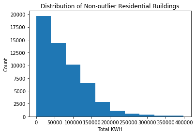

```python
plt.hist(chi_electric[(chi_electric['Municipal'] == 0) & (chi_electric['Industrial'] == 0) & (chi_electric['Commercial'] == 0) & (chi_electric['TOTAL KWH'] < 400000)]['TOTAL KWH'])
plt.xlabel('Total KWH')
plt.ylabel('Count')
plt.title('Distribution of Non-outlier Residential Buildings')
plt.show()
```

Before we go into running some linear regression we want to motivate a crucial modeling choice first. Here we are choosing to run interaction terms even on this subset of residential buildings. As can be see in the figure above there is still a large range of values for total kwh so we must still include our building subtypes associated with residential buildings. They're represented as dummy variables so if we want them to be truly valued in our regression they must be represented by their interactions with the other variables in the set.

```python
# test train split our data first
# remove unnecessary columns
# remove industrial and municipal buildings

no_big = chi_electric[(chi_electric['Municipal'] == 0) & (chi_electric['Industrial'] == 0) & (chi_electric['Commercial'] == 0) & (chi_electric['TOTAL KWH'] < 400000)]
x = no_big.drop(columns = ['CENSUS BLOCK','BUILDING_SUBTYPE', 'KWH MEAN 2010',  'TOTAL KWH'])

poly = PolynomialFeatures(degree=2, interaction_only=True)
x = poly.fit_transform(x)
y = no_big['TOTAL KWH']

# test train split for coefficient visualization later on
X_train, X_test, y_train, y_test = train_test_split(x, y, test_size=0.2, random_state = 21)

lr = LinearRegression()
scores = cross_val_score(lr, x, y, cv = 10)
print(np.mean(scores))

# note this fit is for coefficient visualzation and evaluation later on
lr.fit(X_train, y_train)
```

```
0.8037405488974099
```

```
LinearRegression(copy_X=True, fit_intercept=True, n_jobs=None,
         normalize=False)
```

We get a cross validated R^2 of 0.803 on our data set. We are working with some large coefficient values in our set so let's try some Lasso to see if we get performacne imporovement as well understand if there are coefficients that are not as pressing as regular linear regression might make them out to be.

```python
from sklearn.model_selection import GridSearchCV

params = {'alpha': [1e-2, 1, 10]}

lasso = Lasso()
lasso_regress = GridSearchCV(lasso, params, cv = 3)

lasso_regress.fit(X_train, y_train)

print(lasso_regress.best_params_)
print(lasso_regress.best_score_)

# note this is for coefficient visualization and evaluation later on
lasso = Lasso(alpha = 0.01)
lasso.fit(X_train, y_train)
```

```
{'alpha': 0.01}
0.8023747306807976
```

```
Lasso(alpha=0.01, copy_X=True, fit_intercept=True, max_iter=1000,
   normalize=False, positive=False, precompute=False, random_state=None,
   selection='cyclic', tol=0.0001, warm_start=False)
```

We limited our implementation of our Lasso cross validation because of the computational issues that arise with running cross validation with this many samples. In the end we still see a similar R^2 as our simple linear regression above. We decided to use un-normalized values and also interaction terms so our coefficients may not be directly interpretable but let's see what's going on anyways.

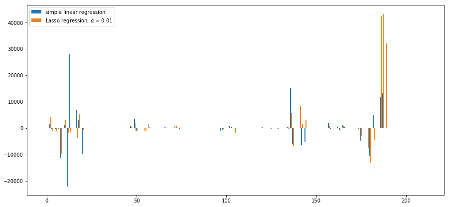

```python
ind = np.arange(len(lr.coef_))
width = 0.5
plt.figure(figsize = (15,7))
plt.bar(ind-(width/2), width = width, height = lr.coef_, label = "simple linear regression")
plt.bar(ind+(width/2), width = width, height = lasso.coef_, label = r"Lasso regression, $\alpha$ = 0.01")
plt.legend()
```

For the most part Lasso is doing a heavy amount of shrinkage but some of our interaction variables are actually getting a great degree of a bump instead.

There are likely some non linearities in play here so it's worthwhile that we explore a different modeling technique, like a Random Forest.

Since we're dealing with a random forest we don't have to feed in interaction variables so I'll reintroduce some the non-poly transformed dataset that we had before

```python
# set X_train, y_train to our non-poly transformed data
x = no_big.drop(columns = ['CENSUS BLOCK','BUILDING_SUBTYPE', 'KWH MEAN 2010',  'TOTAL KWH'])
X_train, X_test, y_train, y_test = train_test_split(x, y, test_size=0.2, random_state = 21)


# we will create different parameter arrays to perform cv search over
n_estimators = [int(x) for x in np.linspace(start = 25, stop = 100, num = 4)]
max_features = ['auto', 'sqrt']
max_depth = [int(x) for x in np.linspace(3, 6, num = 4)]
min_samples_split = [2, 5, 10]
min_samples_leaf = [1, 2, 4]
bootstrap = [True, False]

# Create the random grid
param_grid = {'max_depth': max_depth}


regressor = RandomForestRegressor(n_estimators = 100)

rf_grid = grid_search = GridSearchCV(estimator = regressor, param_grid = param_grid,
                          cv = 3, n_jobs = -1, verbose = 2)
rf_grid.fit(X_train, y_train)

rf_grid.best_params_

best_grid = grid_search.best_estimator_
#regressor.fit(X_train, y_train)
#pred = regressor.predict(X_test)
#regressor.score(X_test, y_test)
```

```
Fitting 3 folds for each of 4 candidates, totalling 12 fits
```

```
[Parallel(n_jobs=-1)]: Using backend LokyBackend with 4 concurrent workers.
[Parallel(n_jobs=-1)]: Done  12 out of  12 | elapsed:   47.8s remaining:    0.0s
[Parallel(n_jobs=-1)]: Done  12 out of  12 | elapsed:   47.8s finished
```

```python
best_grid.score(X_test, y_test)
```

```
0.7894193161996974
```

Our RandomForest here does worse than lasso in this instance. While we weren't able to run grid search as we would've wanted due to the size of data we're working with. But even in this instance of a semi cross validated RandomForest model we'd only have minimal difference in overall accuracy.

### 2. Predicting Month-to-Month Instead of Yearly

We see that we can perform to a reasonable degree in predicting the overall year. Can we improve by building models on and predicting for individual months? Thankfully our data is situated as such that we can explore this.

We'll need to turn each column of monthly values into one categorical variable.

```python
# prepare melted dataset
melt_cols = ['COMMUNITY AREA NAME', 'CENSUS BLOCK',
       'BUILDING_SUBTYPE','TOTAL KWH', 'ELECTRICITY ACCOUNTS', 'ZERO KWH ACCOUNTS',
       'TOTAL THERMS', 'GAS ACCOUNTS',
        'KWH MEAN 2010',
        'KWH TOTAL SQFT',
        'TOTAL POPULATION', 'TOTAL UNITS', 'AVERAGE STORIES',
       'AVERAGE BUILDING AGE', 'AVERAGE HOUSESIZE', 'OCCUPIED UNITS',
       'OCCUPIED UNITS PERCENTAGE',
       'RENTER-OCCUPIED HOUSING PERCENTAGE',
             'Household Income by Race',
        'KWH JANUARY 2010', 'KWH FEBRUARY 2010',
       'KWH MARCH 2010', 'KWH APRIL 2010', 'KWH MAY 2010', 'KWH JUNE 2010',
       'KWH JULY 2010', 'KWH AUGUST 2010', 'KWH SEPTEMBER 2010',
       'KWH OCTOBER 2010', 'KWH NOVEMBER 2010', 'KWH DECEMBER 2010']
melt = chi[melt_cols]
# insert dummy cols for building sub type
dummy_sub = pd.get_dummies(melt['BUILDING_SUBTYPE'])
melt = pd.concat([melt, dummy_sub], axis = 1)

# clean up ELECTRICITY and ZERO KW ELECTRICITY ACCOUNTS columns
melt.replace('Less than 4', 3, inplace = True)

# transform
id_cols = ['COMMUNITY AREA NAME', 'CENSUS BLOCK',
       'BUILDING_SUBTYPE','TOTAL KWH', 'ELECTRICITY ACCOUNTS', 'ZERO KWH ACCOUNTS',
       'TOTAL THERMS', 'GAS ACCOUNTS',
        'KWH MEAN 2010',
        'KWH TOTAL SQFT',
        'TOTAL POPULATION', 'TOTAL UNITS', 'AVERAGE STORIES',
       'AVERAGE BUILDING AGE', 'AVERAGE HOUSESIZE', 'OCCUPIED UNITS',
       'OCCUPIED UNITS PERCENTAGE',
       'RENTER-OCCUPIED HOUSING PERCENTAGE',
          'Household Income by Race']
melt = melt.melt(id_vars =  id_cols, var_name = 'Month')
melt.dropna(inplace = True)

# dummy cols for month
dummy_sub = pd.get_dummies(melt['Month'])
melt = pd.concat([melt, dummy_sub], axis = 1)

# final melted dataset where our monthly categories are transformed.
melt = melt[(melt['Municipal'] == 0) & (melt['Industrial'] == 0) & (melt['Commercial'] == 0) & (melt['TOTAL KWH'] < 400000)]
```

```python
melt.head()
```

|  | COMMUNITY AREA NAME | CENSUS BLOCK | BUILDING_SUBTYPE | TOTAL KWH | ELECTRICITY ACCOUNTS | ZERO KWH ACCOUNTS | TOTAL THERMS | GAS ACCOUNTS | KWH MEAN 2010 | KWH TOTAL SQFT | TOTAL POPULATION | TOTAL UNITS | AVERAGE STORIES | AVERAGE BUILDING AGE | AVERAGE HOUSESIZE | OCCUPIED UNITS | OCCUPIED UNITS PERCENTAGE | RENTER-OCCUPIED HOUSING PERCENTAGE | Household Income by Race | Month | value | Commercial | Industrial | KWH APRIL 2010 | KWH AUGUST 2010 | KWH DECEMBER 2010 | KWH FEBRUARY 2010 | KWH JANUARY 2010 | KWH JULY 2010 | … |
| --- | --- | --- | --- | --- | --- | --- | --- | --- | --- | --- | --- | --- | --- | --- | --- | --- | --- | --- | --- | --- | --- | --- | --- | --- | --- | --- | --- | --- | --- | --- |
| 103 | 38 | 1.703107e+14 | Multi 7+ | 15665.0 | 4 | 3 | 4780.0 | 6 | 7832.50 | 7524.0 | 61.0 | 22.0 | 4.0 | 12.0 | 2.77 | 22.0 | 1.0000 | 0.500 | 104803.0 | KWH JANUARY 2010 | 242.0 | 0 | 0 | 0 | 0 | 0 | 0 | 1 | 0 | … |
| 104 | 38 | 1.703107e+14 | Multi 7+ | 5357.0 | 8 | 12 | 5324.0 | 15 | 1339.25 | 5500.0 | 111.0 | 88.0 | 4.0 | 0.0 | 1.79 | 62.0 | 0.7045 | 0.629 | 116364.0 | KWH JANUARY 2010 | 0.0 | 0 | 0 | 0 | 0 | 0 | 0 | 1 | 0 | … |
| 120 | 40 | 1.703183e+14 | Commercial | 68474.0 | 7 | 0 | 5487.0 | 5 | 68474.00 | 2351.0 | 101.0 | 39.0 | 1.0 | 0.0 | 2.59 | 39.0 | 1.0000 | 0.282 | 84207.0 | KWH JANUARY 2010 | 6171.0 | 0 | 0 | 0 | 0 | 0 | 0 | 1 | 0 | … |
| 131 | 47 | 1.703108e+14 | Multi < 7 | 32429.0 | 4 | 2 | 4301.0 | 4 | 32429.00 | 5804.0 | 36.0 | 18.0 | 3.0 | 116.0 | 2.00 | 18.0 | 1.0000 | 0.667 | 16411.0 | KWH JANUARY 2010 | 1959.0 | 0 | 0 | 0 | 0 | 0 | 0 | 1 | 0 | … |
| 188 | 62 | 1.703183e+14 | Multi 7+ | 48292.0 | 9 | 6 | 10623.0 | 11 | 16097.33 | 4364.0 | 100.0 | 42.0 | 1.0 | 0.0 | 2.94 | 34.0 | 0.8095 | 0.618 | 27791.0 | KWH JANUARY 2010 | 3295.0 | 0 | 0 | 0 | 0 | 0 | 0 | 1 | 0 | … |

Now with our properly "melted" dataset, let's run 12 separate regressions for each month to see what kind of performance we get. The cell below runs the same regression process but trains on and predicts for values within a given month. The January regression model is trained on January data and evaluated on a test set of January data, and so on and so forth.

```python
# train on values within a given month, predict on test set values that are also within the same month
months = ['KWH JANUARY 2010', 'KWH FEBRUARY 2010',
       'KWH MARCH 2010', 'KWH APRIL 2010', 'KWH MAY 2010', 'KWH JUNE 2010',
       'KWH JULY 2010', 'KWH AUGUST 2010', 'KWH SEPTEMBER 2010',
       'KWH OCTOBER 2010', 'KWH NOVEMBER 2010', 'KWH DECEMBER 2010']
r_2scores = []
for i in months:
    m = melt[melt[i] == 1]
    x = m.drop(columns = ['CENSUS BLOCK','BUILDING_SUBTYPE', 'KWH MEAN 2010',  'TOTAL KWH', 'value', 'Month'])
    y = m['value']

    poly = PolynomialFeatures(degree=2, interaction_only=True)
    x = poly.fit_transform(x)

    # test train split
    X_train, X_test, y_train, y_test = train_test_split(x, y, test_size=0.2, random_state = 21)

    lr = LinearRegression(normalize = True)
    lr.fit(X_train, y_train)
    pred = lr.predict(X_test)
    r_2scores.append(lr.score(X_test, y_test))
```

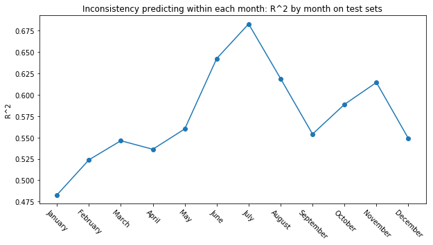

```python
month = ['January', 'February', 'March', 'April', 'May', 'June', 'July', 'August', 'September', 'October', 'November', 'December']
fig, (ax1) = plt.subplots(1, figsize=(10,5))
plt.plot(np.array(month), np.array(r_2scores) , marker = 'o')
plt.ylabel('R^2')
plt.title('Inconsistency predicting within each month: R^2 by month on test sets')
plt.xticks(rotation = -45)
plt.show()
```

We see the troubles that can arise with predicting residential buildings, even when splitting things down to a month by month basis. I'm not sure why this is the way it is, maybe there is too much variance within months to account for with the data we have. Part of this analysis was to see how well non-weather data would perform considering we're evaluating on one city in one month where everyone experiences the same weather conditions. But the only time we see somewhat improved accuracy are in the warmer months. There may be more detailed socioeconomic factors here that could help explain some of our noise.

Now we switch to the other kinds of buildings in our set. Can we accurately predict for commercial/municipal/industrial buildings?

```python
# subsetting for non-residential buildings
big = chi_electric[(chi_electric['BUILDING_SUBTYPE'] == 'Commercial') | (chi_electric['BUILDING_SUBTYPE'] == 'Industrial') | (chi_electric['BUILDING_SUBTYPE'] == 'Municipal')]
```

```python
x = big.drop(columns = ['CENSUS BLOCK','BUILDING_SUBTYPE', 'KWH MEAN 2010',  'TOTAL KWH'])


y = big['TOTAL KWH']

# test train split
X_train, X_test, y_train, y_test = train_test_split(x, y, test_size=0.2, random_state = 21)

lr = LinearRegression(normalize = True)
lr.fit(X_train, y_train)
pred = lr.predict(X_test)
lr.score(X_test, y_test)
```

```
0.23852618964088768
```

### 3. Year-to-Year Consistency?

Zooming out, we've seen the noise that comes with attempting to predict month-to-month but we've seen some more reliability when it comes to predicting for an entire year. What is the variance in total electrical consumption from year-to-year? How might a model we develop hold up under these conditions?

There was a lack of data on individual residential buildings like we found in our Chicago set but there is more available access to yearly electricity consumption for municipal buildings. Here we have data for municipal buildings over multi-year spans for Allegheny County, the city of Chicago, and New York state.

```python
all_county["Property GFA - Self-Reported (sqft)"] =  all_county[[all_county.columns[3]]]
all_county.head()
```

|  | Property Id | Property Name | Address 1 | Property GFA - Self-Reported (ft²) | Year Ending | Site EUI (kBtu/ft²) | Weather Normalized Site EUI (kBtu/ft²) | Source EUI (kBtu/ft²) | Weather Normalized Source EUI (kBtu/ft²) | Electricity Use - Grid Purchase (kBtu) | Electricity Use - Grid Purchase (kWh) | Weather Normalized Site Electricity (kWh) | Natural Gas Use (kBtu) | Natural Gas Use (therms) | Weather Normalized Site Natural Gas Use (therms) | District Steam Use (kBtu) | Total GHG Emissions (Metric Tons CO2e) | Total GHG Emissions Intensity (kgCO2e/ft²) | Energy Cost ($) | Energy Cost Intensity ($/ft²) | Property GFA - Self-Reported (sqft) |
| --- | --- | --- | --- | --- | --- | --- | --- | --- | --- | --- | --- | --- | --- | --- | --- | --- | --- | --- | --- | --- | --- |
| 0 | 3575381 | Ammon Recreation Center | 2217 Bedford Ave | 14951 | 2014-09-30 | 125.2 | 121.5 | 232.3 | 225.2 | 721406 | 211432 | 204501 | 1.15011e+06 | 11501.1 | 11193 | Not Available | 206 | 13.8 | 30473 | 2.04 | 14951 |
| 1 | 3575381 | Ammon Recreation Center | 2217 Bedford Ave | 14951 | 2013-09-30 | 143.6 | 146.5 | 239.5 | 245 | 634925 | 186086 | 191115 | 1.51199e+06 | 15119.9 | 15384.7 | Not Available | 207.9 | 13.9 | 32265.3 | 2.16 | 14951 |
| 2 | 3575381 | Ammon Recreation Center | 2217 Bedford Ave | 14951 | 2012-09-30 | 102.4 | 114 | 172.6 | 181.2 | 465002 | 136284 | 128953 | 1.0667e+06 | 10667 | 12644.2 | Not Available | 150.1 | 10 | 25882.1 | 1.73 | 14951 |
| 3 | 3575381 | Ammon Recreation Center | 2217 Bedford Ave | 14951 | 2011-09-30 | 145.8 | 141.3 | 232.7 | 222.7 | 569412 | 166885 | 155904 | 1.61083e+06 | 16108.3 | 15803.5 | Not Available | 200 | 13.4 | 35425.3 | 2.37 | 14951 |
| 4 | 3575381 | Ammon Recreation Center | 2217 Bedford Ave | 14951 | 2010-09-30 | 142.8 | 143.6 | 244.3 | 242.3 | 674784 | 197768 | 191835 | 1.46088e+06 | 14608.8 | 14923.6 | Not Available | 213.2 | 14.3 | 38210.7 | 2.56 | 14951 |

```python
# clean up all_county data
all_county['Property GFA - Self-Reported (sqft)'] = pd.to_numeric(all_county['Property GFA - Self-Reported (sqft)']).replace('Not Available', 0)
all_county['Electricity Use - Grid Purchase (kBtu)'] = all_county['Electricity Use - Grid Purchase (kBtu)'].replace('Not Available', 0)
all_county['year'] = np.array([all_county['Year Ending'][i].year for i in range(len(all_county))])
```

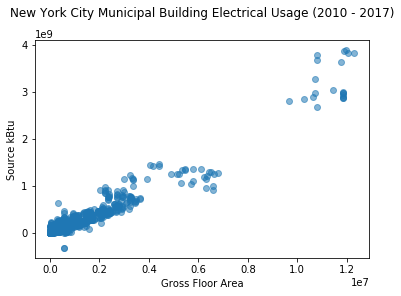

```python
plt.scatter(ny_municipal[' Gross Floor Area  '], ny_municipal['Source kBtu'], alpha = 0.55)
plt.xlabel('Gross Floor Area')
plt.ylabel('Source kBtu')
plt.title('New York City Municipal Building Electrical Usage (2010 - 2017)', y = 1.08)
plt.show()
```

Let's visualize the distributions by year for the buildings in the Chicago set that are present in each year.

```python
vc = (chi_bench['Property Name'].value_counts())
names = vc[vc>3].index.tolist()
chi_bench = chi_bench[chi_bench['Property Name'].isin(names)]
```

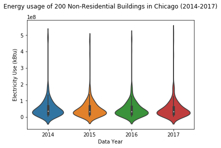

```python
sns.violinplot(x = 'Data Year', y = 'Electricity Use (kBtu)', data = chi_bench )
plt.title('Energy usage of 200 Non-Residential Buildings in Chicago (2014-2017)', y = 1.08)
plt.show()
```

The only meaningful difference comes in the outliers at the top that are consuming nearly five times as much electricity as the rest of the municipal building population.

Let's see how things look in the New York set.

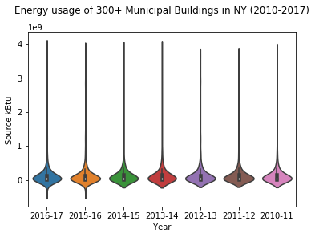

```python
vc_ny = (ny_municipal['Building/Facility Name'].value_counts())
names_ny = vc_ny[vc_ny>6].index.tolist()
ny_muni = ny_municipal[ny_municipal['Building/Facility Name'].isin(names_ny)]


sns.violinplot(x = ' Year ', y = 'Source kBtu', data = ny_muni )
plt.title('Energy usage of 300+ Municipal Buildings in NY (2010-2017)', y = 1.08)

plt.show()
```

Again a similar situation that caused trouble in our other sets. Behavior year-to-year seems fairly steady but the outliers are significant.

Let's see finally what the Allegheny County set looks like.

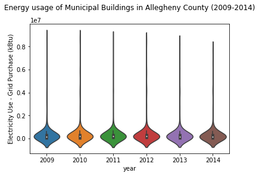

```python
vc_all = (all_county['Property Name'].value_counts())
names_all = vc_all[vc_all>5].index.tolist()
all_muni = all_county[all_county['Property Name'].isin(names_ny)]


sns.violinplot(x = 'year', y = 'Electricity Use - Grid Purchase (kBtu)', data = all_county )
plt.title('Energy usage of Municipal Buildings in Allegheny County (2009-2014)', y = 1.08)


plt.show()
```

Again the same kind of situation across three different areas. Electricity usage as a whole tends to remain constant year-to-year for municipal size buildings, but we'd need year-to-year data for individual residential buildings to have better confirmation that our residential model could work.

### 0. Overview of Modeling Strategy

As mentioned at the end of the EDA section, my approach acknowledges the stark weaknesses in robust citywide energy data availability, so instead of perceiving success as obtaining the highest $R^2$, my intention in exploring three modeling approaches is to use them to guide bias-variance tuning in the basically untrimmed energy intensity range, by comparing training $R^2$ with testing $R^2$, which also indirectly tunes mean squared error.

### 1. Linear Regression - Is a Linear Feature Space Best?

```python
# Train Test Split - Both normalized data and unscaled data (preserved for regression tree)

X_train, X_test, y_train, y_test = train_test_split(X_all_vars_normalized, y_all_vars, test_size = 0.30, random_state = 123456)
```

```python
lm_tract = LinearRegression()
lm_tract.fit(X_train, y_train)
y_pred_train = lm_tract.predict(X_train)

# Score
print("R^2 Score (Training):",  lm_tract.score(X_train,y_train))
print("R^2 Score (Testing):", lm_tract.score(X_test, y_test))
print("Cross-Validated Score:", np.mean(cross_val_score(lm_tract, X_all_vars_normalized, y_all_vars, cv = 10)))
```

```
('R^2 Score (Training):', 0.18220914140709288)
('R^2 Score (Testing):', -0.49894204339885206)
('Cross-Validated Score:', -0.6354224703187904)
```

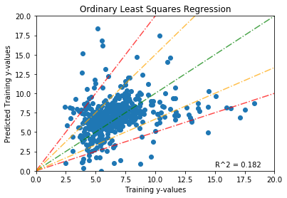

```python
plot_strength(X_train, y_train, y_pred_train, "Ordinary Least Squares Regression", "Training", lm_tract)
```

```python
poly = PolynomialFeatures(degree=3, interaction_only=True)
X_norm_poly = poly.fit_transform(X_all_vars_normalized)

X_train, X_test, y_train, y_test = train_test_split(X_norm_poly, y_all_vars, test_size=0.3, random_state = 21)

lr = LinearRegression()
lr.fit(X_train, y_train)

y_pred_train = lr.predict(X_train)

print("R^2 Score (Training):",  lr.score(X_train,y_train))
print("R^2 Score (Testing):", lr.score(X_test, y_test))
print("Cross-Validated Score:", np.mean(cross_val_score(lr, X_norm_poly, y_all_vars, cv = 10)))
```

```
('R^2 Score (Training):', 1.0)
('R^2 Score (Testing):', -2691.6046019288806)
('Cross-Validated Score:', -15752.602923745402)
```

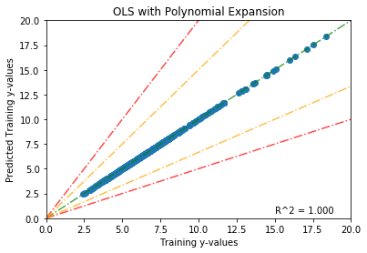

```python
plot_strength(X_train, y_train, y_pred_train, "OLS with Polynomial Expansion", "Training", lr)
```

At a first glance, it seems like we have very little strength in the ordinary linear model, perhaps because there are some nonlinear parameter-response relationships at play. We do not have the worst bias-variance trade-off here, as we will see when the next modeling technique used really contrasts with what we have now.

Since the ultimate goal for me is not to make the most resilient rather than the most biased model, I want to find a modeling technique that is in between both extremes, so I move next to shrinkage methods to see if I can tune a parameter penalty in hopes of improving my model.

Ultimately, some nonlinear fit would be preferred, but polynomial expansion on an ordinary least-squares regression proves to boost the flexibility too quickly.

### 2. Incorporating Shrinkage - Ridge

```python
# Ridge using Original Feature Space

X_train, X_test, y_train, y_test = train_test_split(X_all_vars_normalized, y_all_vars, test_size = 0.30, random_state = 123456)

ri = Ridge()
ri.fit(X_train, y_train)

y_pred_train = ri.predict(X_train)

print("R^2 Score (Training):", ri.score(X_train, y_train))
print("R^2 Score (Testing):", ri.score(X_test, y_test))
print("Cross-Validated Score:", np.mean(cross_val_score(ri, X_all_vars_normalized, y_all_vars, cv = 10)))
```

```
('R^2 Score (Training):', 0.019339321849336177)
('R^2 Score (Testing):', 0.06131535933588783)
('Cross-Validated Score:', 0.0382661813078717)
```

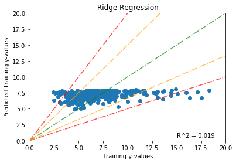

```python
plot_strength(X_train, y_train, y_pred_train, "Ridge Regression", "Training", ri)
```

```python
# Ridge using Polynomial Expansion of Feature Space

X_train, X_test, y_train, y_test = train_test_split(X_norm_poly, y_all_vars, test_size=0.3, random_state = 21)

ri2 = Ridge()
ri2.fit(X_train, y_train)

y_pred_train = ri2.predict(X_train)

print("R^2 Score (Training):",  ri2.score(X_train,y_train))
print("R^2 Score (Testing):", ri2.score(X_test, y_test))
print("Cross-Validated Score:", np.mean(cross_val_score(ri2, X_norm_poly, y_all_vars, cv = 10)))
```

```
('R^2 Score (Training):', 0.027303325301570536)
('R^2 Score (Testing):', 0.040292398235924454)
('Cross-Validated Score:', 0.052984883654825475)
```

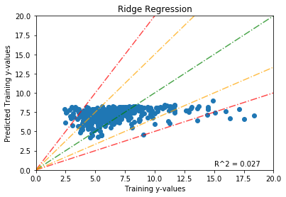

```python
plot_strength(X_train, y_train, y_pred_train, "Ridge Regression", "Training", ri2)
```

Across training performance, Ridge squashes the score down by a factor of ten, but we see a notable improvement in testing and cross-validation scores, suggesting that we have improved the resilience of the model overall. Again, objectively these scores suggest that we are developing almost a constant model, but this is something we expect given the heavy skew and variance across observed energy use intensity in Chicago.

Next, we want to tune our hyperparameter alpha using a grid search cross-validation method in order to explore any other improvements we can make with the Ridge method.

```python
# Cross-validation is performed on polynomial-expanded feature space

parameters = {'alpha': [.001, .05,.1, .5, 1]}


clf = GridSearchCV(Ridge(), parameters, cv=10)

clf.fit(X_train, y_train)
y_pred_train = clf.predict(X_train)
y_pred_test = clf.predict(X_test)

print(clf.best_params_)
```

```
{'alpha': 0.1}
```

```python
rcv = Ridge(alpha=0.05)
rcv.fit(X_train, y_train)

y_pred_train = rcv.predict(X_train)
y_pred_test = rcv.predict(X_test)

print("R^2 Score (Training):", clf.score(X_train, y_train))
print("R^2 Score (Testing):", clf.score(X_test, y_test))
print("Cross-Validated Score:", np.mean(cross_val_score(rcv, X_norm_poly, y_all_vars, cv = 10)))
```

```
('R^2 Score (Training):', 0.04759867387347916)
('R^2 Score (Testing):', 0.05786088179982107)
('Cross-Validated Score:', 0.07165728647172884)
```

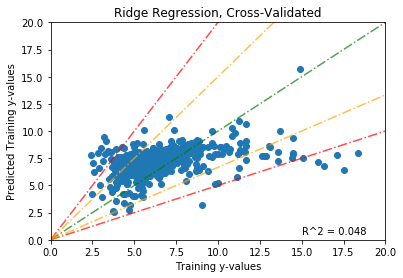

```python
plot_strength(X_train, y_train, y_pred_train, "Ridge Regression, Cross-Validated", "Training", clf)
```

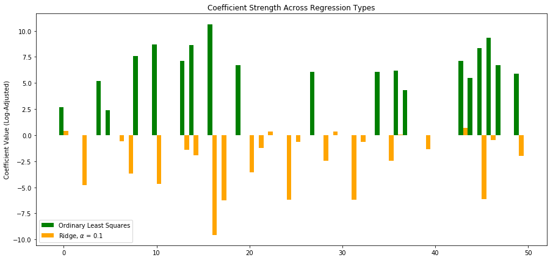

```python
ind = np.arange(len(lm_tract.coef_[0]))
width = 0.5
plt.figure(figsize = (15,7))
plt.bar(ind-(width/2), width = width, height = np.log(lm_tract.coef_[0]), label = "Ordinary Least Squares", color='green')
plt.bar(ind+(width/2), width = width, height = np.log(ri.coef_[0]), label = r"Ridge, $\alpha$ = 0.1", color='orange')
plt.ylabel("Coefficient Value (Log-Adjusted)")
plt.title("Coefficient Strength Across Regression Types")
plt.legend()
plt.show()
```

Using Ridge alpha tuning via model cross-validation, training, testing, and cross-validated $R^2$ scores all increased, maintaining a healthy bias-variance balance while increasing the predictive strength of the model. This excercise further elucidates the importance of model cross-validation because it helps us understand how we can improve our model, what role the penalty factor alpha is playing in highlighting feature importance.

From the graoh of log-transformed coefficients, we observe that the Ridge coefficients were squashed down to almost zero as part of the penalty for including many parameters, but also becuase Ridge is trying to limit the flexibility of the model to hopefully boost its strength.

Because we normalized our features beforehand, we could infer something about feature importance by looking at which coefficients are highest, but because we used the polynomial transformation which does not preserve parameter names, we cannot yet deduce which parameters are most important in predicting energy end-use intensity for a given census tract.

To remedy this, we turn to regression trees next. We do not need to normalize, nor do we need to account for nonlinearity via polynomial expansion here.

### 3. Regression Tree - Pulling Feature Importance

```python
X_train, X_test, y_train, y_test = train_test_split(X_all_vars, y_all_vars, test_size = 0.30, random_state = 123456)
```

```python
clf = GradientBoostingRegressor()
clf = clf.fit(X_train, y_train)

y_pred_train = clf.predict(X_train)
y_pred_test = clf.predict(X_test)
print('Train Score: ', clf.score(X_train, y_train))
print('Validation Score: ', clf.score(X_test, y_test))
print("Cross-Validated Score:", np.mean(cross_val_score(clf, X_all_vars, y_all_vars, cv = 10)))
```

```
('Train Score: ', 0.9730562660377459)
('Validation Score: ', -0.10354714824875068)
('Cross-Validated Score:', -2.3740600539188055)
```

```python
parameters = {'loss' : ['ls', 'lad'],
              #'learning_rate': [.001, .05, .1, .5, 1],
              'subsample': [.75, .9, .95],
              'min_samples_split': np.arange(5,15)
             }


clf2 = GridSearchCV(GradientBoostingRegressor(), parameters, cv=5)

clf2.fit(X_train, y_train)
y_pred_train = clf2.predict(X_train)
y_pred_test = clf2.predict(X_test)

print(clf2.best_params_)
```

```
{'min_samples_split': 13, 'loss': 'lad', 'subsample': 0.75}
```

For computational efficiency, I cannot use hyperparameter tuning via model cross-validation on all of my parameters of interest at once, so the parameters I specify below are based on stratified model cross-validation, although I recognize that the best parameter values may change with different combinations of hyperparameters.

Ultimately, I kept the learning rate as the default value, while the cross-validation demonstrated that the least absolute deviation loss function, less sensitive to outliers, would give me a more resilient model overall. Additionally, cross-validation indicated that I should only be using 75% of my feature space in my initial split in order to be able to explore various split patterns, instead of always leading with the same initial split that may be restricting me from other model-strengthening pathways.

```python
clf3 = GradientBoostingRegressor(min_samples_split = 10, loss='lad', subsample=.75)
clf3 = clf3.fit(X_train, y_train)

y_pred_train = clf3.predict(X_train)
y_pred_test = clf3.predict(X_test)
print('Train Score: ', clf3.score(X_train, y_train))
print('Validation Score: ', clf3.score(X_test, y_test))
print("Cross-Validated Score:", np.mean(cross_val_score(clf3, X_all_vars, y_all_vars, cv = 10)))
```

```
('Train Score: ', 0.05135246265880621)
('Validation Score: ', 0.10307044699977573)
('Cross-Validated Score:', 0.09976339266906675)
```

Again, we observe that model cross-validation significantly lowers my training fit to where I am dangerously close to a constant model, but this again can probably be attributed to the non-normal nature of my energy end-use intensity distribution across census tract. What significantly improves is both the testing and the cross-validation performance, signalling that the Gradient Boost regression is the best performer so far in terms of tuning bias-variance.

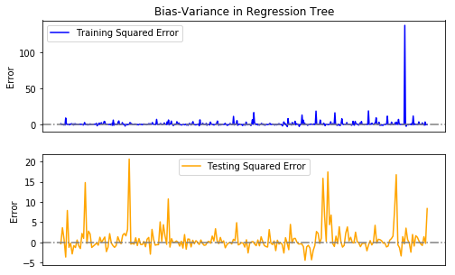

```python
num_points1 = np.arange(len(y_train))
num_points2 = np.arange(len(y_test))

fig, (ax1, ax2) = plt.subplots(2, figsize=(8,5))

ax1.plot(num_points1, (y_train["KWH/M^2 INTENSITY"].values - y_pred_train.reshape(len(y_train))), color='blue', label="Training Squared Error")
ax1.legend()
ax1.set_xticks([])
ax1.set_ylabel("Error")
ax1.axhline(0, color='grey', linestyle='-.')

ax2.plot(num_points2, (y_test["KWH/M^2 INTENSITY"].values - y_pred_test.reshape(len(y_test))), color='orange', label="Testing Squared Error")
ax2.legend()
ax2.set_xticks([])
ax2.set_ylabel("Error")
ax2.axhline(0, color='grey', linestyle='-.')

ax1.set_title("Bias-Variance in Regression Tree")

plt.show()
```

```python
feature_importance = clf3.feature_importances_
importance_df = pd.DataFrame({'Feature':X_train.columns, 'Importance':feature_importance})
importance_df.sort_values(by="Importance", ascending=False).head()
```

|  | Feature | Importance |
| --- | --- | --- |
| 0 | AVERAGE BUILDING AGE COMM 7+ | 0.092773 |
| 21 | MEDIAN INCOME | 0.080206 |
| 41 | RENTER-OCCUPIED HOUSING UNITS RDTL <7 | 0.066739 |
| 13 | AVERAGE HOUSESIZE SINGLE FAMILY | 0.058296 |
| 1 | AVERAGE BUILDING AGE COMM <7 | 0.056311 |

Moreover, from the regression tree I can pull information about feature importance, which I have not been able to directly do yet due to the necessity of applying a polynomial expansion to my feature space to capture nonlinear feature-response relationships.

Here, we see that Average Building Age, Household Median Income, Occupied Housing Units, Housesize, and Building Age contribute the most to energy end-use intensity along census tracts.

**Please note** that this table is different from what is included in out poster presentation, and this is because I have changed my regression tree method from a Random Forest Regressor because I wanted to make sure I included more model-selection flexibility, and because I was drawn more to the resilience of the model built using the Gradient Boosting Regressor. However, between both snapshots of feature importance, we observe the commonality of Occupied Housing Units and Average Building Age coming up as top performers.

In addition, it is notable that the Median Income predictor contributed significantly to the prediction, which points us back to the question of whether we can use predicted energy end-use intensity as effective metrics of welfare. Because there is a significant association between the two, and we commonly use income as an indicator of welfare, we can conclude that consumption intensity can aid in completing our picture of how "well-off" an area is.

### 4. K-Nearest-Neighbors Regression - Analyzing the "What if"

Even after teasing out information about feature importance, I don't want to conclude my city-wide analysis without at least studying the hypothetical approach of just pruning the extreme outliers that form the large skew. Thus, in this section, I use the "lazy" regression of K Nearest Neighbors on a subset of my data that only includes energy intensities up until 20 $kWh/m^2$ (which is about where the kernel density estimate plot drops off back in the EDA I performed.

```python
X_norm_pruned = X_all_vars_normalized[y_all_vars["KWH/M^2 INTENSITY"] <= 20 ]
y_pruned = y_all_vars[y_all_vars["KWH/M^2 INTENSITY"] <= 20 ]
```

```python
X_train, X_test, y_train, y_test = train_test_split(X_norm_pruned, y_pruned, test_size = 0.30, random_state = 123456)
```

```python
parameters = {'n_neighbors': [2,5,8,11],
              'leaf_size': [5, 10, 15, 20],
              'weights': ['uniform', 'distance']
}
```

```python
knn = KNeighborsRegressor()
knn = knn.fit(X_train, y_train)

y_pred_train = knn.predict(X_train)
y_pred_test = knn.predict(X_test)
print('Train Score: ', knn.score(X_train, y_train))
print('Validation Score: ', knn.score(X_test, y_test))
print("Cross-Validated Score:", np.mean(cross_val_score(knn, X_norm_pruned, y_pruned, cv = 10)))
```

```
('Train Score: ', 0.40902544202854857)
('Validation Score: ', 0.08857853327781984)
('Cross-Validated Score:', 0.07275297046909299)
```

```python
knn2 = GridSearchCV(KNeighborsRegressor(), parameters, cv=10)

knn2.fit(X_train, y_train)
y_pred_train = knn2.predict(X_train)
y_pred_test = knn2.predict(X_test)
print(knn2.best_params_)

print("R^2 Score (Training):", knn2.score(X_train, y_train))
print("R^2 Score (Testing):", knn2.score(X_test, y_test))
print("Cross-Validated Score:", np.mean(cross_val_score(knn2, X_norm_pruned, y_pruned, cv = 10)))
```

```
{'n_neighbors': 11, 'weights': 'distance', 'leaf_size': 5}
('R^2 Score (Training):', 1.0)
('R^2 Score (Testing):', 0.10876027285178559)
('Cross-Validated Score:', 0.12348487569242832)
```

```python
knn3 = KNeighborsRegressor(n_neighbors = 11,
                          weights = 'distance',
                          leaf_size = 5)
knn3 = knn3.fit(X_train, y_train)

y_pred_train = knn3.predict(X_train)
y_pred_test = knn3.predict(X_test)
print('Train Score: ', knn3.score(X_train, y_train))
print('Validation Score: ', knn3.score(X_test, y_test))
print("Cross-Validated Score:", np.mean(cross_val_score(knn3, X_norm_pruned, y_pruned, cv = 10)))
```

```
('Train Score: ', 1.0)
('Validation Score: ', 0.10876027285178559)
('Cross-Validated Score:', 0.1251743389625272)
```

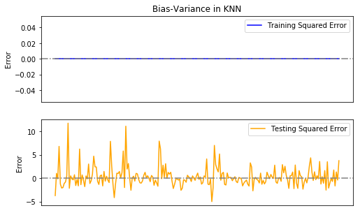

```python
num_points1 = np.arange(len(y_train))
num_points2 = np.arange(len(y_test))

fig, (ax1, ax2) = plt.subplots(2, figsize=(8,5))

ax1.plot(num_points1, (y_train["KWH/M^2 INTENSITY"].values - y_pred_train.reshape(len(y_train))), color='blue', label="Training Squared Error")
ax1.legend()
ax1.set_xticks([])
ax1.set_ylabel("Error")
ax1.axhline(0, color='grey', linestyle='-.')

ax2.plot(num_points2, (y_test["KWH/M^2 INTENSITY"].values - y_pred_test.reshape(len(y_test))), color='orange', label="Testing Squared Error")
ax2.legend()
ax2.set_xticks([])
ax2.set_ylabel("Error")
ax2.axhline(0, color='grey', linestyle='-.')

ax1.set_title("Bias-Variance in KNN")

plt.show()
```

After performing model cross-validation on our modified energy end-use intensity value range, we observe at best, with the cross-validated model, the same testing and cross-validation strength in the model as with the regression tree, suggesting that we would have probably not had quite a strong model even with some of the outliers removed. Depending on our model tuning strategies, we can take on the position of a city planner who aims to examine city-wide consumption behaviors and include all data values and still get a relatively resilient model.

### 5. Exploration of Howard et al.

In "Spatial distribution of urban building energy consumption by end use", a study is performed to use regression methods to predict energy consumption on a census block area using just a square footage parameter diffused into each building type. Effectively, the objective was to determine a coefficient of energy usage intensity ($kWh/m^2$). So, while fitting a spatial regression in order to make some conclusions about a city, I was motivated to recreate this analysis for Chicago, and to cross-reference our results with existing data from our robust Chicago Energy dataset.

```python
# REPEAT SOME OF OUR DATA CLEANING BUT NOW JUST ON SQUARE FOOTAGE

# Create a new dataframe that is grouped by census tract, where each sqaure footage
# is totaled for the census tract, but this total is split amongst each building type we consider.

for i in range(len(census_tracts)):
    current_tract_df = chicago_all_vars[ chicago_all_vars["CENSUS TRACT"] == census_tracts[i]]
    dict_tract = {}

    single_family = current_tract_df[current_tract_df["BUILDING_SUBTYPE"]  == 'Single Family'][ "KWH TOTAL SQFT" ].sum()
    res_7plus = current_tract_df[(current_tract_df["BUILDING TYPE"]  == "Residential") &
                        (current_tract_df["BUILDING_SUBTYPE"]  == "Multi 7+")]["KWH TOTAL SQFT"].sum()
    res_7less = current_tract_df[(current_tract_df["BUILDING TYPE"]  == "Residential") &
                        (current_tract_df["BUILDING_SUBTYPE"]  == "Multi < 7")][ "KWH TOTAL SQFT" ].sum()
    comm_7plus = current_tract_df[(current_tract_df["BUILDING TYPE"]  == "Commercial") &
                        (current_tract_df["BUILDING_SUBTYPE"]  == "Commercial")][ "KWH TOTAL SQFT" ].sum()
    comm_7less = current_tract_df[(current_tract_df["BUILDING TYPE"]  == "Commercial") &
                        (current_tract_df["BUILDING_SUBTYPE"]  == "Multi < 7")][ "KWH TOTAL SQFT" ].sum()
    industrial = current_tract_df[(current_tract_df["BUILDING TYPE"]  == "Industrial")][ "KWH TOTAL SQFT"].sum()
    municipal = current_tract_df[(current_tract_df["BUILDING_SUBTYPE"]  == "Municipal")][ "KWH TOTAL SQFT" ].sum()
    dict_tract.update(
    {"SQFT"+" "+"SINGLE FAMILY": single_family,
         "SQFT"+" "+building_types[0]: res_7plus,
         "SQFT"+" "+building_types[1]: res_7less,
         "SQFT"+" "+building_types[2]: comm_7plus,
         "SQFT"+" "+building_types[3]: comm_7less,
         "SQFT"+" "+"INDUSTRIAL": industrial,
         "SQFT"+" "+"MUNICIPAL": municipal,
         "TOTAL KWH": [current_tract_df['TOTAL KWH'].sum()],
         "TOTAL EUI": [current_tract_df['TOTAL KWH'].sum() / current_tract_df['KWH TOTAL SQFT'].sum()]
    })
    to_cat = pd.DataFrame(data = dict_tract)
    if i > 0:
        chicago_sqft_by_type = pd.concat([chicago_sqft_by_type, to_cat]).reset_index(drop=True)
    else:
        chicago_sqft_by_type = to_cat

chicago_sqft_by_type.head()
```

|  | SQFT COMM 7+ | SQFT COMM <7 | SQFT INDUSTRIAL | SQFT MUNICIPAL | SQFT RDTL 7+ | SQFT RDTL <7 | SQFT SINGLE FAMILY | TOTAL EUI | TOTAL KWH |
| --- | --- | --- | --- | --- | --- | --- | --- | --- | --- |
| 0 | 131908.0 | 7699.0 | 0.0 | 0.0 | 0.0 | 182380.0 | 136847.0 | 8.634709 | 4152518.0 |
| 1 | 249816.0 | 22012.0 | 0.0 | 0.0 | 17661.0 | 121104.0 | 2381504.0 | 7.878727 | 22171723.0 |
| 2 | 258985.0 | 94693.0 | 0.0 | 15075.0 | 85016.0 | 883739.0 | 562788.0 | 5.447974 | 10953979.0 |
| 3 | 169799.0 | 107478.0 | 0.0 | 0.0 | 53838.0 | 994215.0 | 339476.0 | 6.491285 | 10806730.0 |
| 4 | 1145078.0 | 113989.0 | 0.0 | 0.0 | 33578.0 | 1290894.0 | 549700.0 | 5.533954 | 17382403.0 |

```python
# Separate the partially cleaned dataframe into the predictors and the response variable
X_all_vars = chicago_sqft_by_type.drop(["TOTAL KWH", "TOTAL EUI"], axis=1).reset_index(drop=True)
y_all_vars = chicago_sqft_by_type[["TOTAL KWH"]]
```

```python
# Do one more sweep, through the predictor space now, and remove any tracts who are missing more than
# one variable but who also (upon previous inspection) have uncharacteristically high consumption totals
discard_array = []

for i in range(len(X_all_vars)):
    zero_counter = 0
    for indx in range(1,len(X_all_vars.columns)):
        if X_all_vars.iloc[i, indx] == 0.0:
            zero_counter += 1
    if zero_counter > len(X_all_vars.columns)*0.5:
        discard_array = np.append(discard_array, 1)
    else:
        discard_array = np.append(discard_array, 0)
```

```python
X_all_vars["Rows to Discard"] = discard_array
y_all_vars["Rows to Discard"] = discard_array
```

```python
X_all_vars = X_all_vars[X_all_vars["Rows to Discard"] == 0].reset_index(drop=True).drop("Rows to Discard", axis=1) # 775
y_all_vars = y_all_vars[y_all_vars["Rows to Discard"] == 0].reset_index(drop=True).drop("Rows to Discard", axis=1)
```

```python
X_all_vars.columns
```

```
Index([u'SQFT COMM 7+', u'SQFT COMM <7', u'SQFT INDUSTRIAL', u'SQFT MUNICIPAL',
       u'SQFT RDTL 7+', u'SQFT RDTL <7', u'SQFT SINGLE FAMILY'],
      dtype='object')
```

```python
# Perform an OLS Regression

# Remove parameters that are sparse, or that on average contribute to tail-end of square footage distribution
X_pruned = X_all_vars.drop(["SQFT MUNICIPAL", "SQFT INDUSTRIAL", "SQFT SINGLE FAMILY"], axis=1)

lm = LinearRegression()
lm.fit(X_pruned, y_all_vars)
lm.predict(X_pruned)
print("Coefficients:", lm.coef_)
```

```
('Coefficients:', array([[16.30082326, -6.95156486,  0.28213927,  2.88661741]]))
```

```python
print("Sum of Coefficients on Pruned Model:",lm.coef_.sum())
print("Average of Census Tracts' EUI:", chicago_sqft_by_type["TOTAL EUI"].mean())
```

```
('Sum of Coefficients on Pruned Model:', 12.5180150868335)
("Average of Census Tracts' EUI:", 7.478616205316302)
```

# Interpretation and Conclusions (20 points)

The core objective of our analysis was to predict energy consumption while modeling on a citywide scale. We achieved this my splitting our approach in two sections: one that considered the effects of time-changing quantities and forecasted across months and years, and one that looked across space and predicted on the census tract level to make an observation about the city it is within.

Looking at the spatial forecasting component of this analysis, the main takeaway is that for a city whose consumption distribution is highly non-symmetric, developing a robust model that has this "one-size-fits-all" character is difficult and sometimes futile. There is much variation that exists on this scale, so it is almost predetermined that models will either be overfit to their training set while failing to predict accurately on testing or validation sets, or will approach a constant model with just slight perturbations in their ability to match flexibility. As a result, we took a tour through some classical modeling approaches in order to highlight how performance improves once we incorporate nonlinear predictor-response relationships, and once we start tuning hyperparameters that indirectly control model error.

There is a great deal that can be told from square footage alone in predicting electricity output. When it comes to predicting on the level of individual residential buildings we can predict electricity consumption fairly well on a yearly timescale. However for whatever reason in the data we're working with there is a great drop in trying predicting individual electric consumption on a monthly scale. This is something that begs to be looked into further before even attempt to build a future model on a monthly scale. As it stands now that our model can only accurately predict for yearly electricity consumption is limited in applicability. We are still dealing with a great deal of noise in our residential data and additional building information data, especially appliance information, would likely go a great way in covering for these gaps.

Given the strength of square footage as a predictor, we sought out to see how well we could estimate electrical consumption from non-square-footage predictors and found that most of the accuracy can be made up without square footage. While we certainly imagined that there would be solidly linear relationships that did not require much data transformation, the building characteristic data was not specific enough or electrical consumption is simply too noisy to estimate with the data we have. We had to use interaction variables since we were performing ordinary least squares regression and Lasso and it made a substantial boost in accuracy. When looking through the model coefficients for our OLS and Lasso models, we were surprised to see that there were a number of coefficients that Lasso had actually boosted. The boosted coefficients appear to be interaction variables which signals there are strong data pairs in our building types but that maybe we should be building separate models for the different subtypes instead of treating the subtypes as a binary dummy variable.

It would not necessarily be advised to apply any of these models to other cities as there are likely weather characteristics that are driving electricity consumption trends. But for a city planner or official looking to better understand future electricity consumption, there is more data that needs to be collected but they largely can rely on previous models fitted on their city's or region's data.